# Household Travel Survey, 2017 and 2019: Household Vehicle Count

Mary Richards

March 15, 2021

This report presents preliminary findings for household vehicle count trends based on the Household Travel Survey (2017 and 2019), a survey conducted every other year to determine travel patterns for individuals living within PSRC’s four-county jurisdiction.

## 1. Background Information

This work helps to supplement PSRC’s SoundCast Auto Ownership Model (https://www.psrc.org/sites/default/files/2015psrc-modechoiceautomodels.pdf, 2015). According to the results from this model, the most predictive variables are the number of drivers and workers in the household, along with household income. In addition to these variables, the model also considers additional traveler/household characteristics (such as age of household members per driver), transportation level of service variables (such as distance to transit stop and number of transit stops), and land use variables (such as service and retail density).

The following sections describe the process to understand the important factors that contribute to household vehicle access and count.

## 2. Dependent Variables

The two potential dependent variables for these models are at the household level (by `household_id`):

1. Vehicle count - the number of vehicles owned (reported by survey respondents)
2. Vehicle access - the number of household vehicles owned in relation to the number of workers in each household

### a. Household Vehicle Count

Survey Responses:  
*“How many motor vehicles (in working order) are there in your household?”*

|  | Overall (N=6319) |
| --- | --- |
| vehcount_ordered |  |
| 0 (no vehicles) | 1111 (18%) |
| 1 | 3033 (48%) |
| 2 | 1681 (27%) |
| 3 | 349 (6%) |
| 4 | 101 (2%) |
| 5 | 34 (1%) |
| 6 | 5 (0%) |
| 7 | 2 (0%) |
| 8 | 1 (0%) |
| 9 | 1 (0%) |
| 10 or more vehicles | 1 (0%) |

```
## # A tibble: 11 x 5
##    vehcount_ordered        n sum_wt_comb perc_comb   MOE
##    <fct>               <int>       <dbl>     <dbl> <dbl>
##  1 0 (no vehicles)      1111      129694      7.83  1.04
##  2 1                    3033      512485     30.9   1.04
##  3 2                    1681      624905     37.7   1.04
##  4 3                     349      267392     16.1   1.04
##  5 4                     101       63642      3.84  1.04
##  6 5                      34       45050      2.72  1.04
##  7 6                       5        7367      0.44  1.04
##  8 7                       2        2626      0.16  1.04
##  9 8                       1         298      0.02  1.04
## 10 9                       1         385      0.02  1.04
## 11 10 or more vehicles     1        2910      0.18  1.04
```

Based on survey responses, there is a very small number of households with more than 3 vehicles, so these households are grouped together.

|  | Overall (N=6319) |
| --- | --- |
| vehicle_group |  |
| 0 | 1111 (18%) |
| 1 | 3033 (48%) |
| 2 | 1681 (27%) |
| 3 | 494 (8%) |

```
## # A tibble: 4 x 5
##   vehicle_group     n sum_wt_comb perc_comb   MOE
##   <fct>         <int>       <dbl>     <dbl> <dbl>
## 1 0              1111      129694      7.83  1.04
## 2 1              3033      512485     30.9   1.04
## 3 2              1681      624905     37.7   1.04
## 4 3               494      389671     23.5   1.04
```

### b. Household Vehicle Access

This variable is based on the number of household vehicles (explained above) and the number of workers within the household.

|  | Overall (N=6319) |
| --- | --- |
| numworkers |  |
| 0 | 1190 (19%) |
| 1 | 2920 (46%) |
| 2 | 2054 (33%) |
| 3 | 131 (2%) |
| 4 | 20 (0%) |
| 5 | 4 (0%) |

```
## # A tibble: 6 x 5
##   numworkers     n sum_wt_comb perc_comb   MOE
##   <fct>      <int>       <dbl>     <dbl> <dbl>
## 1 0           1190      324848     19.6   1.04
## 2 1           2920      624264     37.7   1.04
## 3 2           2054      573546     34.6   1.04
## 4 3            131      107521      6.49  1.04
## 5 4             20       23914      1.44  1.04
## 6 5              4        2662      0.16  1.04
```

Based on survey responses, there is a very small number of households with more than 3 workers, so these households are grouped together

|  | Overall (N=6319) |
| --- | --- |
| numworkers_group |  |
| 0 | 1190 (19%) |
| 1 | 2920 (46%) |
| 2 | 2054 (33%) |
| 3 | 155 (2%) |

```
## # A tibble: 4 x 5
##   numworkers_group     n sum_wt_comb perc_comb   MOE
##   <fct>            <int>       <dbl>     <dbl> <dbl>
## 1 0                 1190      324848     19.6   1.04
## 2 1                 2920      624264     37.7   1.04
## 3 2                 2054      573546     34.6   1.04
## 4 3                  155      134097      8.09  1.04
```

**Vehicle Access is calculated by comparing the number of vehicles and the number of workers per household**

- *limited access*: vehicles < workers
- *equal access*: vehicles = workers
- *good access*: vehicles > workers

|  | Overall (N=6319) |
| --- | --- |
| hh_veh_access |  |
| Reduced access | 4632 (73%) |
| Equal access | 1233 (20%) |
| Good access | 454 (7%) |

Although vehicle access is an interesting measurement to explore, it requires a few levels of aggregation and adjustment, which could introduce error or oversimplification. Therefore, analysis will be based on the count of vehicles per household.

## 3. Explanatory or predictor variables

There are many personal and household characteristics that can contribute to vehicle count at the household level.  
Based on these considerations and the data available through survey responses, the following table will attempt to match the person-level and household-level characteristics with responses provided by the survey participants. The data listed in the right column are from the in-house person (p) and household (h) views, available through Elmer, or describe an externally-sourced dataset (e).

Vehicle-ownership Considerations

Survey Variables

1. Income

*hhincome_broad (p/h), hhincome_detailed (p/h)*

2. Gender

*gender (p)*

3. Age

*age (p), age_category (p)*

4. Household size

*hhsize (p/h)*

5. Number of licensed (or licensed age) individuals

*license (p)*

6. Occupation

*employment (p), jobs_count (p)*

7. Educational Attainment

*education (p)*

8. Number of workers

*numworkers (h)*

9. Household lifecycle or age composition of household members

*lifecycle (p/h)*

10. Race or ethnicity

*race_category (p)*

11. Physical disabilities

*?*

12. Housing type

*rent_own (h), res_type (h)*

13. Housing or work location and proximity to transit

*final_home_rgcnum (h), seattle_home (h)*

14. Commuting patterns

*commute_freq (p), commute_mode (p), commute_dur (p), telecommute_freq (p)*

15. Quality of transit options available

*transit score by block group (e)*

16. Housing proximity to services

*displacement risk index (e)*

17. Environmental consciousness

*?*

Because the dependent variable is household vehicle count, the person-level variables need to be aggregated to the household level. With this in mind, gender and employment type were removed from this analysis.  
The table below illustrates the person-level variables related to vehicle count and the way in which they were aggregated:

Person-level variables

Aggregation method(s)

Number of licensed (or licensed age) individuals

sum

Number of jobs

sum

Educational Attainment

min, max

Commuting Patterns

- Distance (mi) by automobile
- Time (min) by automobile
- Commute frequency (days/week)

mean, sum

mean, sum

min, max

In addition to these variables, two additional ones were calculated:

- Number of household jobs per worker (sum of household jobs/numworkers)
- Number of household commute trips per week (sum of household commute trips/(numworkers*5))

### a. Univariate analysis

The dependent variable or outcome will be vehicle count (`vehicle_group`: 0, 1, 2, 3+) and the independent or explanatory variables will be from the list above. Because the vehicle count is ordinal, an ordered logit model will be applied.

The following section will introduce descriptive statistics for each of the explanatory variables, followed by analysis. For an overview of the results from these individual analyses, please skip to section 3b.

#### *1. Income*

|  | Overall (N=6319) |
| --- | --- |
| hhincomeb_reordered |  |
| Under $25,000 | 633 (10%) |
| $25,000-$49,999 | 937 (15%) |
| $50,000-$74,999 | 948 (15%) |
| $75,000-$99,999 | 835 (13%) |
| $100,000 or more | 2545 (40%) |
| Prefer not to answer | 421 (7%) |

| hhincomeb_reordered | Percentage_0 | Percentage_1 | Percentage_2 | Percentage_3 | Total_0 | Total_1 | Total_2 | Total_3 | Count_0 | Count_1 | Count_2 | Count_3 | sample_size | MOE_Percent |
| --- | --- | --- | --- | --- | --- | --- | --- | --- | --- | --- | --- | --- | --- | --- |
| Under $25,000 | 33.933469 | 54.07767 | 9.802108 | 2.186754 | 58826.180 | 93747.64 | 16992.68 | 3790.90 | 299 | 283 | 43 | 8 | 633 | 3.269144 |
| $25,000-$49,999 | 11.689098 | 43.19336 | 36.549599 | 8.567947 | 28316.046 | 104632.96 | 88538.92 | 20755.27 | 245 | 525 | 140 | 27 | 937 | 2.686990 |
| $50,000-$74,999 | 7.141843 | 45.53108 | 32.026498 | 15.300581 | 17458.994 | 111305.56 | 78292.18 | 37403.90 | 162 | 522 | 210 | 54 | 948 | 2.671356 |
| $75,000-$99,999 | 3.498465 | 30.11401 | 42.230896 | 24.156634 | 7142.927 | 61484.71 | 86224.15 | 49321.36 | 98 | 433 | 235 | 69 | 835 | 2.846379 |
| $100,000 or more | 2.105206 | 15.48069 | 45.803297 | 36.610804 | 13962.697 | 102675.10 | 303788.60 | 242819.75 | 242 | 1075 | 928 | 300 | 2545 | 1.630392 |
| Prefer not to answer | 3.084233 | 29.88920 | 39.503767 | 27.522801 | 3987.139 | 38639.22 | 51068.44 | 35580.07 | 65 | 195 | 125 | 36 | 421 | 4.008620 |

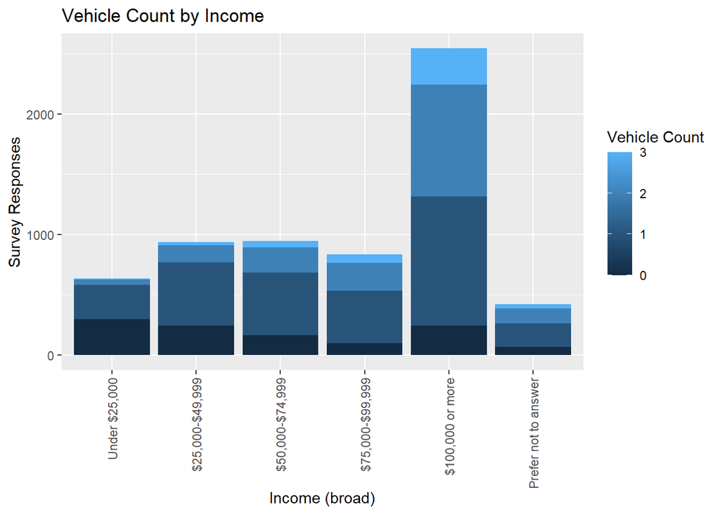

Reference group: Under $25,000

```
##                                   Value Std. Error t value       p-value
## explanatory$25,000-$49,999       0.8918     0.0989  9.0152  1.964551e-19
## explanatory$50,000-$74,999       1.4340     0.0999 14.3612  9.063829e-47
## explanatory$75,000-$99,999       1.8306     0.1030 17.7685  1.238541e-70
## explanatory$100,000 or more      2.2577     0.0896 25.2086 3.222315e-140
## explanatoryPrefer not to answer  1.8028     0.1227 14.6907  7.393120e-49
## 0|1                             -0.0958     0.0766 -1.2516  2.107235e-01
## 1|2                              2.3508     0.0836 28.1297 4.245880e-174
## 2|3                              4.2655     0.0938 45.4915  0.000000e+00
##                                 simp p. odds ratio
## explanatory$25,000-$49,999       0.0000     2.4395
## explanatory$50,000-$74,999       0.0000     4.1955
## explanatory$75,000-$99,999       0.0000     6.2374
## explanatory$100,000 or more      0.0000     9.5611
## explanatoryPrefer not to answer  0.0000     6.0667
## 0|1                              0.2107     2.4395
## 1|2                              0.0000     4.1955
## 2|3                              0.0000     6.2374
```

**Vehicle Count by Income**

|  | *Dependent variable:* |
| --- | --- |
|  | outcome |
| 49,999 | 0.892*** |
|  | (0.099) |
| 74,999 | 1.434*** |
|  | (0.100) |
| 99,999 | 1.831*** |
|  | (0.103) |
| 100,000 or more | 2.258*** |
|  | (0.090) |
| explanatoryPrefer not to answer | 1.803*** |
|  | (0.123) |
| Observations | 6,319 |
| *Note:* | <sup>⋆</sup>p<0.1; <sup>⋆⋆</sup>p<0.05; <sup>⋆⋆⋆</sup>p<0.01 |

In reference to the households making under $25k, households in higher income categories are more likely to own more vehicles. This positive association between household income and household vehicle count is statistically significant.

#### *2. Age/Lifecycle*

Person-level ages are likely to influence household vehicle count, but because the variable of interest is vehicle count, the household age composition or household lifecycle will be evaluated.

Households were organized into four categories based on the composition and age of people in the household:

- *Households with children:* any household with at least one member under age 18
- *Households with younger adults:* any household without children where all adults are age 18-34
- *Households with older adults:* any household without children where all adults are age 18-64 and at least one adult is age 35-64
- *Households with seniors:* any household with at one adult age 65 and older

|  | Overall (N=6319) |
| --- | --- |
| lifecycle |  |
| Household includes children age 5-17 | 513 (8%) |
| Household includes children under 5 | 518 (8%) |
| Household size = 1, Householder age 35 - 64 | 1222 (19%) |
| Household size = 1, Householder age 65+ | 525 (8%) |
| Household size = 1, Householder under age 35 | 863 (14%) |
| Household size > 1, Householder age 35 - 64 | 1095 (17%) |
| Household size > 1, Householder age 65+ | 536 (8%) |
| Household size > 1, Householder under age 35 | 1047 (17%) |

Because of the large number of categories - accounting for both size and age, they are reduced to reflect only age ranges

|  | Overall (N=6319) |
| --- | --- |
| hh_lifecycle |  |
| Under age 35 | 1910 (30%) |
| Age 35-64 | 2317 (37%) |
| Age 65+ | 1061 (17%) |
| With children under 5 | 518 (8%) |
| With children age 5-17 | 513 (8%) |

| hh_lifecycle | Percentage_0 | Percentage_1 | Percentage_2 | Percentage_3 | Total_0 | Total_1 | Total_2 | Total_3 | Count_0 | Count_1 | Count_2 | Count_3 | sample_size | MOE_Percent |
| --- | --- | --- | --- | --- | --- | --- | --- | --- | --- | --- | --- | --- | --- | --- |
| Under age 35 | 16.0654874 | 46.52870 | 31.48164 | 5.924173 | 48082.586 | 139256.30 | 94221.76 | 17730.53 | 501 | 1037 | 330 | 42 | 1910 | 1.881998 |
| Age 35-64 | 10.2718636 | 35.42334 | 28.30109 | 26.003704 | 54996.879 | 189661.12 | 151527.69 | 139227.18 | 427 | 1163 | 529 | 198 | 2317 | 1.708728 |
| Age 65+ | 6.7513583 | 33.65705 | 33.62075 | 25.970841 | 22970.012 | 114510.70 | 114387.23 | 88360.08 | 156 | 499 | 291 | 115 | 1061 | 2.525098 |
| With children under 5 | 0.5941147 | 14.27629 | 64.66386 | 20.465730 | 1047.200 | 25163.73 | 113978.04 | 36073.38 | 12 | 182 | 279 | 45 | 518 | 3.613858 |
| With children age 5-17 | 0.8500118 | 14.36484 | 49.34866 | 35.436489 | 2597.304 | 43893.35 | 150790.26 | 108280.09 | 15 | 152 | 252 | 94 | 513 | 3.631426 |

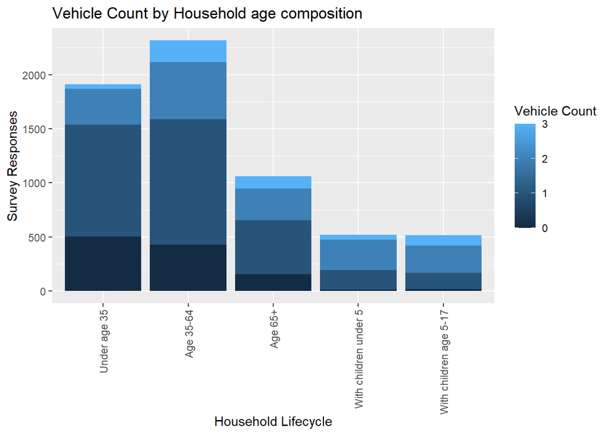

Reference group: Under age 35

```
##                                     Value Std. Error  t value       p-value
## explanatoryAge 35-64               0.5877     0.0593   9.9149  3.584629e-23
## explanatoryAge 65+                 0.9023     0.0738  12.2351  2.018171e-34
## explanatoryWith children under 5   1.7231     0.0909  18.9487  4.522939e-80
## explanatoryWith children age 5-17  2.0239     0.0941  21.5033 1.450611e-102
## 0|1                               -0.9874     0.0462 -21.3819 1.970587e-101
## 1|2                                1.3762     0.0483  28.5104 8.716811e-179
## 2|3                                3.3324     0.0652  51.1391  0.000000e+00
##                                   simp p. odds ratio
## explanatoryAge 35-64                    0     1.7999
## explanatoryAge 65+                      0     2.4654
## explanatoryWith children under 5        0     5.6019
## explanatoryWith children age 5-17       0     7.5680
## 0|1                                     0     1.7999
## 1|2                                     0     2.4654
## 2|3                                     0     5.6019
```

**Vehicle Count by Household Lifecycle**

|  | *Dependent variable:* |
| --- | --- |
|  | outcome |
| explanatoryAge 35-64 | 0.588*** |
|  | (0.059) |
| explanatoryAge 65+ | 0.902*** |
|  | (0.074) |
| explanatoryWith children under 5 | 1.723*** |
|  | (0.091) |
| explanatoryWith children age 5-17 | 2.024*** |
|  | (0.094) |
| Observations | 6,319 |
| *Note:* | <sup>⋆</sup>p<0.1; <sup>⋆⋆</sup>p<0.05; <sup>⋆⋆⋆</sup>p<0.01 |

The relationship between household lifecycle and household vehicle count is statistically significant, with households with children owning more vehicles, especially those with children ages 5-17, likely because of lifestyle requirements and housing patterns. Households with individuals 65+ are more likely to own more vehicles than households ages 35-64, likely because of mobility considerations and housing patterns. All of the household lifecycle categories included in the table above are more likely to own more vehicles than households under age 35.

#### *3. Household size*

The survey question provides respondents with 9 options for household size.  
Original Data

|  | Overall (N=6319) |
| --- | --- |
| hhsize |  |
| 1 person | 2610 (41%) |
| 2 people | 2522 (40%) |
| 3 people | 633 (10%) |
| 4 people | 438 (7%) |
| 5 people | 80 (1%) |
| 6 people | 22 (0%) |
| 7 people | 10 (0%) |
| 8 people | 3 (0%) |
| 9 people | 1 (0%) |

Because there are so few people with more than 5 people, these households have been combined together into one category for analysis.

|  | Overall (N=6319) |
| --- | --- |
| hhsize_simp |  |
| 1 person | 2610 (41%) |
| 2 people | 2522 (40%) |
| 3 people | 633 (10%) |
| 4 people | 438 (7%) |
| 5 or more people | 116 (2%) |

| hhsize_simp_num | Percentage_0 | Percentage_1 | Percentage_2 | Percentage_3 | Total_0 | Total_1 | Total_2 | Total_3 | Count_0 | Count_1 | Count_2 | Count_3 | sample_size | MOE_Percent |
| --- | --- | --- | --- | --- | --- | --- | --- | --- | --- | --- | --- | --- | --- | --- |
| 1 | 20.1919376 | 69.385449 | 9.024234 | 1.39838 | 88646.538 | 304615.632 | 39618.14 | 6139.161 | 804 | 1648 | 131 | 27 | 2610 | 1.609962 |
| 2 | 4.6539384 | 23.514419 | 48.058893 | 23.77275 | 27497.093 | 138931.400 | 283948.73 | 140457.703 | 265 | 1067 | 955 | 235 | 2522 | 1.637809 |
| 3 | 3.8735134 | 16.166098 | 42.030072 | 37.93032 | 10448.146 | 43605.310 | 113369.00 | 102310.601 | 32 | 213 | 273 | 115 | 633 | 3.269144 |
| 4 | 0.9137735 | 7.508204 | 57.665716 | 33.91231 | 2043.703 | 16792.493 | 128972.41 | 75846.658 | 8 | 94 | 260 | 76 | 438 | 3.930057 |
| 5 | 0.7928102 | 6.396670 | 44.188082 | 48.62244 | 1058.502 | 8540.366 | 58996.69 | 64917.119 | 2 | 11 | 62 | 41 | 116 | 7.636721 |

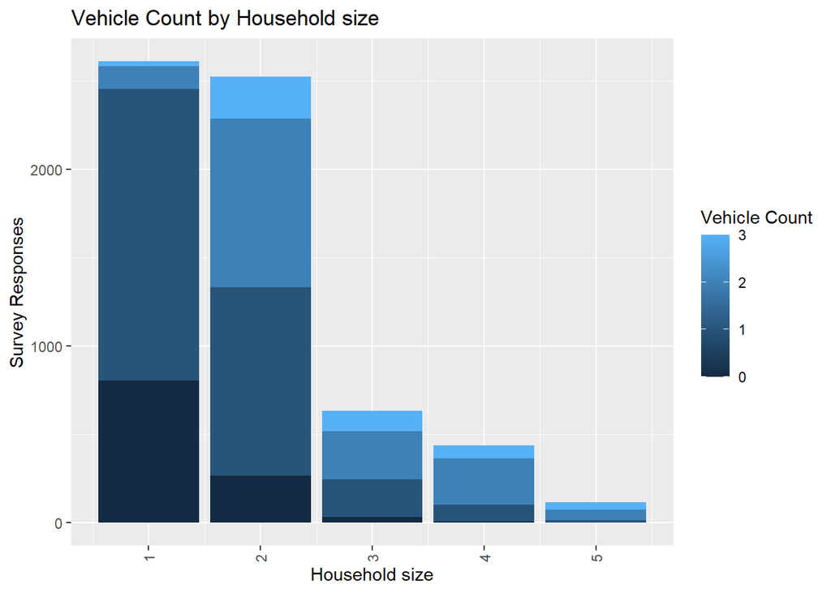

```
##              Value Std. Error t value     p-value simp p. odds ratio
## explanatory 1.0851     0.0282 38.4301 0.000000000  0.0000     2.9596
## 0|1         0.1702     0.0536  3.1720 0.001513787  0.0015     2.9596
## 1|2         2.7888     0.0637 43.8117 0.000000000  0.0000     2.9596
## 2|3         5.0381     0.0895 56.2710 0.000000000  0.0000     2.9596
```

**Vehicle Count by Household size**

|  | *Dependent variable:* |
| --- | --- |
|  | outcome |
| explanatory | 1.085*** |
|  | (0.028) |
| Observations | 6,319 |
| *Note:* | <sup>⋆</sup>p<0.1; <sup>⋆⋆</sup>p<0.05; <sup>⋆⋆⋆</sup>p<0.01 |

#### *4. Number of household licenses*

Original data at a person level (11,940 survey respondents)

|  | Overall (N=11940) |
| --- | --- |
| license |  |
| Missing: Skip logic | 747 (6%) |
| No, does not have a license or permit | 778 (7%) |
| Yes, has a learner’s permit | 120 (1%) |
| Yes, has an intermediate or unrestricted license | 9519 (80%) |
| Missing | 776 (6.5%) |

These categories have been simplified to drivers or non-drivers. Those with a permit are considered to be drivers as they are in the pursuit of a license. Despite this recategorization, there is a large disparity between these groups, with over 10 times as many people reporting that they have a license.

|  | Overall (N=11940) |
| --- | --- |
| license_simp |  |
| Driver | 10415 (87%) |
| Missing | 747 (6%) |
| Non-driver | 778 (7%) |

The person level data of having a license is aggregated to the household level. The following values reflect the number of licenses within each surveyed household (6,319 households).

```
## Frequencies
## person_and_household$hh_driver
## Type: Numeric
##
##               Freq   % Valid   % Valid Cum.   % Total   % Total Cum.
## ----------- ------ --------- -------------- --------- --------------
##           0    289     4.574          4.574     4.574          4.574
##           1   2678    42.380         46.954    42.380         46.954
##           2   2654    42.000         88.954    42.000         88.954
##           3    421     6.662         95.616     6.662         95.616
##           4    236     3.735         99.351     3.735         99.351
##           5     30     0.475         99.826     0.475         99.826
##           6      7     0.111         99.937     0.111         99.937
##           7      3     0.047         99.984     0.047         99.984
##           9      1     0.016        100.000     0.016        100.000
##        <NA>      0                              0.000        100.000
##       Total   6319   100.000        100.000   100.000        100.000
```

Because there are so few households with more than 4 drivers, these categories have been simplified.

```
## Frequencies
## person_and_household$driver_simp
## Type: Numeric
##
##               Freq   % Valid   % Valid Cum.   % Total   % Total Cum.
## ----------- ------ --------- -------------- --------- --------------
##           1    289      4.57           4.57      4.57           4.57
##           2   2678     42.38          46.95     42.38          46.95
##           3   2654     42.00          88.95     42.00          88.95
##           4    421      6.66          95.62      6.66          95.62
##           5    277      4.38         100.00      4.38         100.00
##        <NA>      0                               0.00         100.00
##       Total   6319    100.00         100.00    100.00         100.00
```

Margin of Error

| driver_simp | Percentage_0 | Percentage_1 | Percentage_2 | Percentage_3 | Total_0 | Total_1 | Total_2 | Total_3 | Count_0 | Count_1 | Count_2 | Count_3 | sample_size | MOE_Percent |
| --- | --- | --- | --- | --- | --- | --- | --- | --- | --- | --- | --- | --- | --- | --- |
| 1 | 99.7976806 | 0.1137874 | 0.08853204 | NA | 58372.686 | 66.5554 | 51.7833 | NA | 284 | 4 | 1 | NA | 289 | 4.838235 |
| 2 | 10.9435119 | 77.4493707 | 10.23055251 | 1.376565 | 50793.538 | 359475.7856 | 47484.3871 | 6389.229 | 645 | 1856 | 149 | 28 | 2678 | 1.589391 |
| 3 | 2.4683995 | 17.2870823 | 54.72622450 | 25.518294 | 18192.717 | 127410.0919 | 403345.8723 | 188076.165 | 164 | 1017 | 1186 | 287 | 2654 | 1.596561 |
| 4 | 0.7932645 | 8.5490311 | 33.56844757 | 57.089257 | 1703.912 | 18363.1005 | 72104.1681 | 122626.266 | 15 | 108 | 179 | 119 | 421 | 4.008620 |
| 5 | 0.3462057 | 3.9329136 | 55.90742752 | 39.813453 | 631.130 | 7169.6677 | 101918.7587 | 72579.582 | 3 | 48 | 166 | 60 | 277 | 4.941924 |

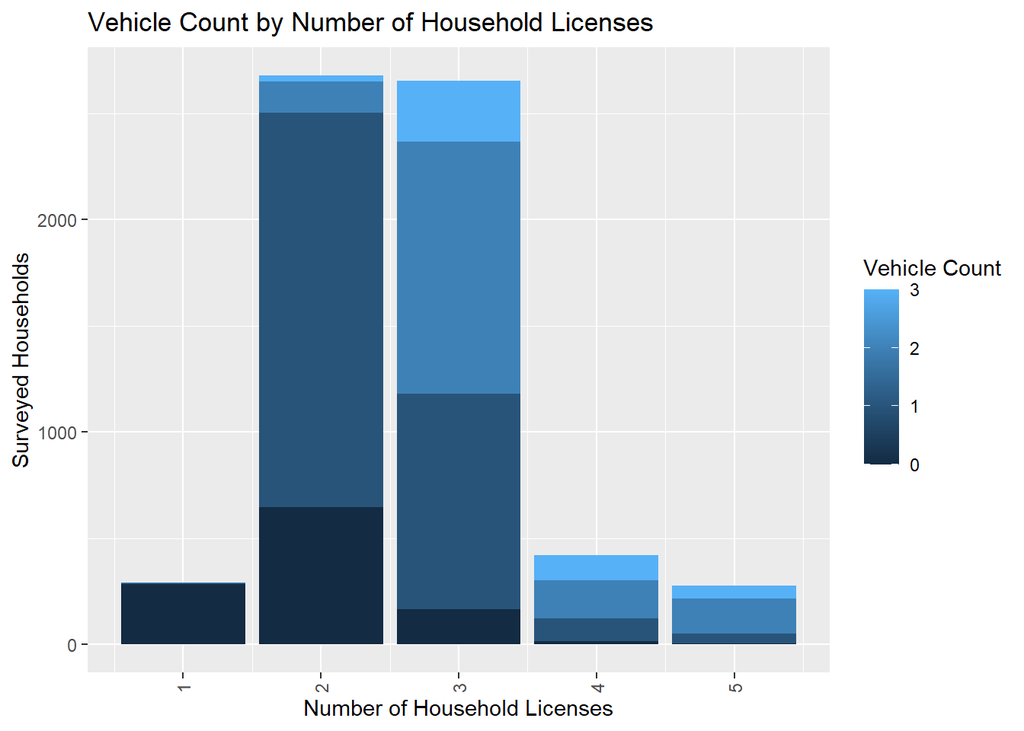

Reference group: 0 licenses in the household

```
##              Value Std. Error t value       p-value simp p. odds ratio
## explanatory 1.6106     0.0362 44.4550  0.000000e+00       0      5.006
## 0|1         2.2021     0.0872 25.2537 1.031591e-140       0      5.006
## 1|2         5.0785     0.1053 48.2515  0.000000e+00       0      5.006
## 2|3         7.4691     0.1307 57.1290  0.000000e+00       0      5.006
```

**Vehicle Count by Number of Household Licenses**

|  | *Dependent variable:* |
| --- | --- |
|  | outcome |
| explanatory | 1.611*** |
|  | (0.036) |
| Observations | 6,319 |
| *Note:* | <sup>⋆</sup>p<0.1; <sup>⋆⋆</sup>p<0.05; <sup>⋆⋆⋆</sup>p<0.01 |

In reference to the households with no licensed members, households with more licensed drivers are more likely to own more vehicles. This positive association between number of household licenses and household vehicle count is statistically significant.

#### *5. Number of workers*

This variable is defined as number of household members with 1+ jobs.

Original data at a household level

```
## Frequencies
## person_and_household$numworkers
## Type: Factor
##
##               Freq   % Valid   % Valid Cum.   % Total   % Total Cum.
## ----------- ------ --------- -------------- --------- --------------
##           0   1190    18.832         18.832    18.832         18.832
##           1   2920    46.210         65.042    46.210         65.042
##           2   2054    32.505         97.547    32.505         97.547
##           3    131     2.073         99.620     2.073         99.620
##           4     20     0.317         99.937     0.317         99.937
##           5      4     0.063        100.000     0.063        100.000
##        <NA>      0                              0.000        100.000
##       Total   6319   100.000        100.000   100.000        100.000
```

|  | Overall (N=6319) |
| --- | --- |
| numworkers_simp |  |
| 1 | 1190 (19%) |
| 2 | 2920 (46%) |
| 3 | 2054 (33%) |
| 4 | 155 (2%) |

| numworkers_simp | Percentage_0 | Percentage_1 | Percentage_2 | Percentage_3 | Total_0 | Total_1 | Total_2 | Total_3 | Count_0 | Count_1 | Count_2 | Count_3 | sample_size | MOE_Percent |
| --- | --- | --- | --- | --- | --- | --- | --- | --- | --- | --- | --- | --- | --- | --- |
| 1 | 15.9871410 | 37.05190 | 32.69776 | 14.26320 | 51933.9266 | 120362.384 | 106218.1 | 46333.74 | 318 | 547 | 245 | 80 | 1190 | 2.384308 |
| 2 | 9.5256602 | 49.00161 | 29.38933 | 12.08340 | 59465.2985 | 305899.543 | 183467.1 | 75432.38 | 622 | 1700 | 469 | 129 | 2920 | 1.522105 |
| 3 | 3.0417116 | 13.43068 | 53.45642 | 30.07118 | 17445.6049 | 77031.079 | 306597.0 | 172471.97 | 167 | 758 | 912 | 217 | 2054 | 1.814829 |
| 4 | 0.6332362 | 6.85487 | 21.34480 | 71.16710 | 849.1526 | 9192.194 | 28622.8 | 95433.15 | 4 | 28 | 55 | 68 | 155 | 6.606479 |

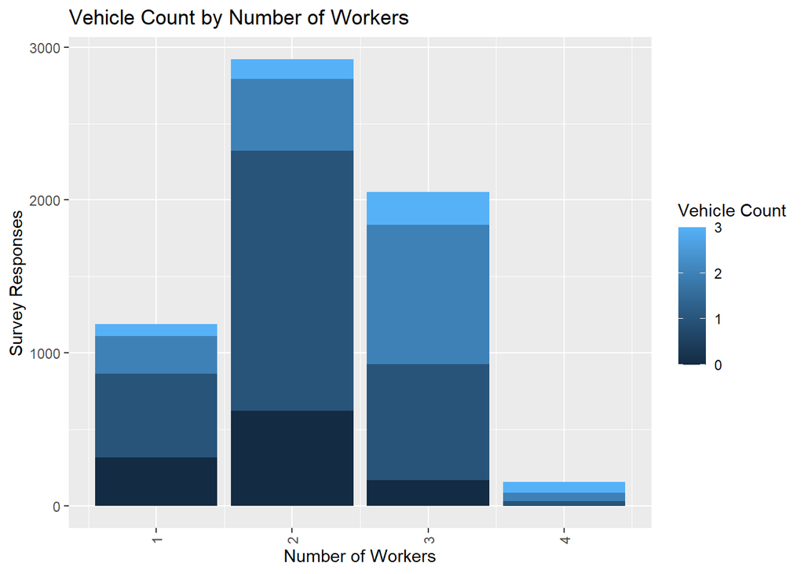

Reference group: 1 person

```
##              Value Std. Error t value       p-value simp p. odds ratio
## explanatory 0.8095     0.0333 24.3093 1.562224e-130  0.0000     2.2469
## 0|1         0.1137     0.0744  1.5282  1.264631e-01  0.1265     2.2469
## 1|2         2.4718     0.0815 30.3450 2.923931e-202  0.0000     2.2469
## 2|3         4.4057     0.0958 45.9980  0.000000e+00  0.0000     2.2469
```

**Vehicle Count by Number of Workers**

|  | *Dependent variable:* |
| --- | --- |
|  | outcome |
| explanatory | 0.810*** |
|  | (0.033) |
| Observations | 6,319 |
| *Note:* | <sup>⋆</sup>p<0.1; <sup>⋆⋆</sup>p<0.05; <sup>⋆⋆⋆</sup>p<0.01 |

In reference to the households with one person, households with more workers are more likely to own more vehicles. This positive association between the number of household workers and household vehicle count is statistically significant.

#### *6. Number of Jobs*

Original data at a person level (11,940 survey respondents)

```
## Frequencies
## person$jobs_count
## Type: Character
##
##                              Freq   % Valid   % Valid Cum.   % Total   % Total Cum.
## ------------------------- ------- --------- -------------- --------- --------------
##                    0 jobs      91      0.94           0.94      0.76           0.76
##                     1 job    6799     70.48          71.42     56.94          57.71
##                    2 jobs     554      5.74          77.16      4.64          62.35
##                    3 jobs      87      0.90          78.07      0.73          63.07
##                    4 jobs      16      0.17          78.23      0.13          63.21
##            5 or more jobs      28      0.29          78.52      0.23          63.44
##       Missing: Skip logic    2072     21.48         100.00     17.35          80.80
##                      <NA>    2293                              19.20         100.00
##                     Total   11940    100.00         100.00    100.00         100.00
```

The person level jobs data is aggregated to the household level. The following table reflects the sum of the jobs held by individuals within each of the surveyed households (6,319).

```
## Frequencies
## person_and_household$hh_jobs
## Type: Numeric
##
##               Freq   % Valid   % Valid Cum.   % Total   % Total Cum.
## ----------- ------ --------- -------------- --------- --------------
##           0   1195    18.911         18.911    18.911         18.911
##           1   2661    42.111         61.022    42.111         61.022
##           2   1947    30.812         91.834    30.812         91.834
##           3    363     5.745         97.579     5.745         97.579
##           4     84     1.329         98.908     1.329         98.908
##           5     44     0.696         99.604     0.696         99.604
##           6     15     0.237         99.842     0.237         99.842
##           7      7     0.111         99.953     0.111         99.953
##          10      2     0.032         99.984     0.032         99.984
##          13      1     0.016        100.000     0.016        100.000
##        <NA>      0                              0.000        100.000
##       Total   6319   100.000        100.000   100.000        100.000
```

##### *Jobs : Worker ratio*

The number of household jobs per worker (sum of household jobs/sum household members with 1+ jobs) was calculated to create a more standardized measurement.

```
##    Min. 1st Qu.  Median    Mean 3rd Qu.    Max.
##  0.0000  0.5000  0.5000  0.5195  0.6667  3.3333
```

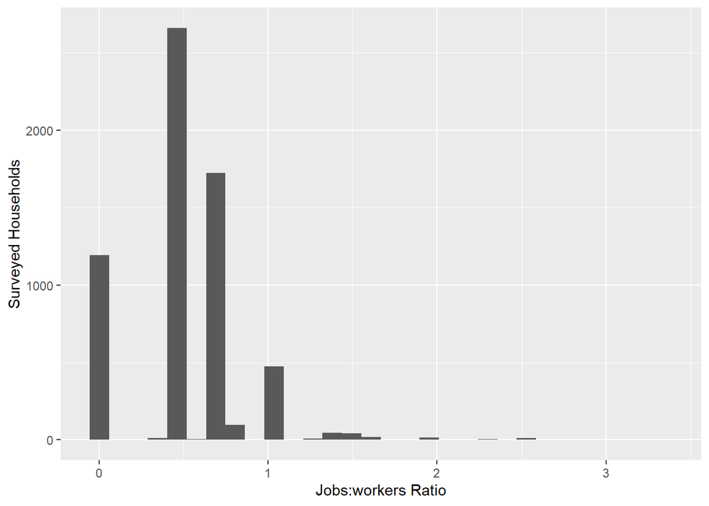

```
##               Value Std. Error  t value       p-value simp p. odds ratio
## explanatory  0.8747     0.0736  11.8888  1.353761e-32       0     2.3982
## 0|1         -1.1164     0.0482 -23.1501 1.451715e-118       0     2.3982
## 1|2          1.1129     0.0479  23.2315 2.188080e-119       0     2.3982
## 2|3          2.9578     0.0633  46.7105  0.000000e+00       0     2.3982
```

**Vehicle Count by jobs:workers ratio**

|  | *Dependent variable:* |
| --- | --- |
|  | outcome |
| explanatory | 0.875*** |
|  | (0.074) |
| Observations | 6,319 |
| *Note:* | <sup>⋆</sup>p<0.1; <sup>⋆⋆</sup>p<0.05; <sup>⋆⋆⋆</sup>p<0.01 |

When there are more jobs/workers within a household, these households are more likely to own more vehicles. This positive association between the number of jobs per household worker and household vehicle count is statistically significant.

#### *7. Educational attainment*

Original data at a person level (11,940 survey respondents)

|  | Overall (N=11940) |
| --- | --- |
| education |  |
| Associates degree | 606 (5%) |
| Bachelor degree | 4182 (35%) |
| Graduate/post-graduate degree | 3312 (28%) |
| High school graduate | 642 (5%) |
| Less than high school | 126 (1%) |
| Missing: Skip logic | 801 (7%) |
| Some college | 1154 (10%) |
| Vocational/technical training | 268 (2%) |
| Missing | 849 (7.1%) |

##### *Survey education categories*

The person level education data is aggregated to the household level. The following tables reflect the lowest and highest educational attainment of the individuals within each of the surveyed households (6,319). The educational attainment categories are ranked based on the number of years of training.  
For example, if a household includes 3 members - one with `Vocational/technical training`, one with a `Bachelor degree`, and one with a `Graduate/post-graduate` degree - the household education minimum would be Vocational/technical training and the household education maximum would be Graduate/post-graduate.

**Lowest Educational Attainment**

```
## Frequencies
## person_and_household$education_min
## Type: Factor
##
##                                       Freq   % Valid   % Valid Cum.   % Total   % Total Cum.
## ----------------------------------- ------ --------- -------------- --------- --------------
##               Less than high school    114      1.80           1.80      1.80           1.80
##                High school graduate    507      8.02           9.83      8.02           9.83
##       Vocational/technical training    218      3.45          13.28      3.45          13.28
##                        Some college    836     13.23          26.51     13.23          26.51
##                   Associates degree    399      6.31          32.82      6.31          32.82
##                     Bachelor degree   2727     43.16          75.98     43.16          75.98
##       Graduate/post-graduate degree   1518     24.02         100.00     24.02         100.00
##                 Missing: Skip logic      0      0.00         100.00      0.00         100.00
##                                <NA>      0                               0.00         100.00
##                               Total   6319    100.00         100.00    100.00         100.00
```

**Highest Educational Attainment**

```
## Frequencies
## person_and_household$education_max
## Type: Factor
##
##                                       Freq   % Valid   % Valid Cum.   % Total   % Total Cum.
## ----------------------------------- ------ --------- -------------- --------- --------------
##               Less than high school     20      0.32           0.32      0.32           0.32
##                High school graduate    187      2.96           3.28      2.96           3.28
##       Vocational/technical training     94      1.49           4.76      1.49           4.76
##                        Some college    593      9.38          14.15      9.38          14.15
##                   Associates degree    337      5.33          19.48      5.33          19.48
##                     Bachelor degree   2495     39.48          58.97     39.48          58.97
##       Graduate/post-graduate degree   2593     41.03         100.00     41.03         100.00
##                 Missing: Skip logic      0      0.00         100.00      0.00         100.00
##                                <NA>      0                               0.00         100.00
##                               Total   6319    100.00         100.00    100.00         100.00
```

###### *Household education minimum*

Margin of Error

| education_min | Percentage_0 | Percentage_1 | Percentage_2 | Percentage_3 | Total_0 | Total_1 | Total_2 | Total_3 | Count_0 | Count_1 | Count_2 | Count_3 | sample_size | MOE_Percent |
| --- | --- | --- | --- | --- | --- | --- | --- | --- | --- | --- | --- | --- | --- | --- |
| Less than high school | 7.520847 | 19.62031 | 39.51936 | 33.33948 | 5845.575 | 15249.88 | 30716.41 | 25913.09 | 23 | 31 | 40 | 20 | 114 | 7.703418 |
| High school graduate | 7.178634 | 20.81265 | 36.04809 | 35.96063 | 19305.465 | 55971.35 | 96943.95 | 96708.74 | 91 | 163 | 163 | 90 | 507 | 3.652851 |
| Vocational/technical training | 2.540707 | 22.62496 | 34.68776 | 40.14657 | 2035.988 | 18130.45 | 27796.94 | 32171.34 | 28 | 73 | 77 | 40 | 218 | 5.570673 |
| Some college | 8.892914 | 28.99027 | 31.35543 | 30.76138 | 28192.664 | 91906.09 | 99404.22 | 97520.93 | 168 | 339 | 226 | 103 | 836 | 2.844676 |
| Associates degree | 7.131113 | 31.34404 | 37.18387 | 24.34097 | 10225.840 | 44946.59 | 53320.76 | 34904.35 | 64 | 171 | 117 | 47 | 399 | 4.117650 |
| Bachelor degree | 6.794764 | 34.20082 | 45.34123 | 13.66319 | 34167.623 | 171979.57 | 227999.38 | 68705.66 | 481 | 1394 | 716 | 136 | 2727 | 1.575046 |
| Graduate/post-graduate degree | 11.219221 | 42.85882 | 33.26802 | 12.65395 | 29920.828 | 114301.27 | 88723.33 | 33747.13 | 256 | 862 | 342 | 58 | 1518 | 2.111057 |

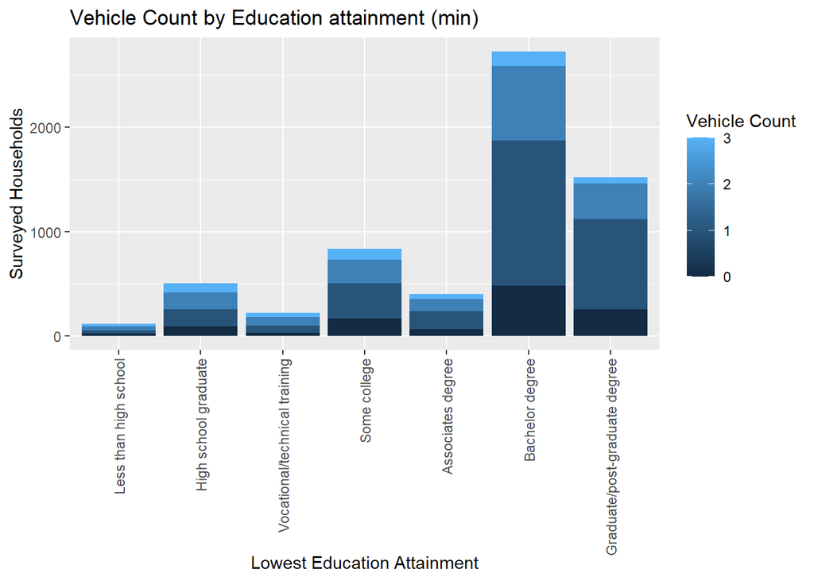

Reference group: Less than high school

```
##                                            Value Std. Error  t value
## explanatoryHigh school graduate          -0.0326     0.2035  -0.1602
## explanatoryVocational/technical training  0.1788     0.2247   0.7957
## explanatorySome college                  -0.4721     0.1960  -2.4081
## explanatoryAssociates degree             -0.3405     0.2072  -1.6438
## explanatoryBachelor degree               -0.7225     0.1878  -3.8473
## explanatoryGraduate/post-graduate degree -0.8379     0.1904  -4.4014
## 0|1                                      -2.1735     0.1867 -11.6439
## 1|2                                       0.0440     0.1846   0.2382
## 2|3                                       1.9014     0.1873  10.1508
##                                               p-value simp p. odds ratio
## explanatoryHigh school graduate          8.727168e-01  0.8727     0.9679
## explanatoryVocational/technical training 4.261986e-01  0.4262     1.1958
## explanatorySome college                  1.603575e-02  0.0160     0.6237
## explanatoryAssociates degree             1.002107e-01  0.1002     0.7114
## explanatoryBachelor degree               1.194247e-04  0.0001     0.4855
## explanatoryGraduate/post-graduate degree 1.075566e-05  0.0000     0.4326
## 0|1                                      2.463494e-31  0.0000     0.9679
## 1|2                                      8.116995e-01  0.8117     1.1958
## 2|3                                      3.288205e-24  0.0000     0.6237
```

**Vehicle Count by Lowest educational attainment**

|  | *Dependent variable:* |
| --- | --- |
|  | outcome |
| explanatoryHigh school graduate | -0.033 |
|  | (0.204) |
| explanatoryVocational/technical training | 0.179 |
|  | (0.225) |
| explanatorySome college | -0.472** |
|  | (0.196) |
| explanatoryAssociates degree | -0.341 |
|  | (0.207) |
| explanatoryBachelor degree | -0.722*** |
|  | (0.188) |
| explanatoryGraduate/post-graduate degree | -0.838*** |
|  | (0.190) |
| Observations | 6,319 |
| *Note:* | <sup>⋆</sup>p<0.1; <sup>⋆⋆</sup>p<0.05; <sup>⋆⋆⋆</sup>p<0.01 |

In reference to the households with less than a high school degree as the lowest educational attainment, households with less education are more likely to own more vehicles while households with more education (“Bachelor degree” and “Graduate/post-graduate degree”) are more likely to own fewer vehicles. This negative association is statistically significant.  
The remaining education categories are either not statistically significant (“Associates degree”) or the MOE is high (“Less than high school”).

###### *Analysis check*

|  | Less than high school (N=126) | High school graduate (N=642) | Vocational/technical training (N=268) | Some college (N=1154) | Associates degree (N=606) | Bachelor degree (N=4182) | Graduate/post-graduate degree (N=3312) | Missing: Skip logic (N=801) | Overall (N=11940) |
| --- | --- | --- | --- | --- | --- | --- | --- | --- | --- |
| age_reordered |  |  |  |  |  |  |  |  |  |
| Under 5 years old | 0 (0%) | 0 (0%) | 0 (0%) | 0 (0%) | 0 (0%) | 0 (0%) | 0 (0%) | 305 (38.1%) | 652 (5.5%) |
| 5-11 years | 0 (0%) | 0 (0%) | 0 (0%) | 0 (0%) | 0 (0%) | 0 (0%) | 0 (0%) | 306 (38.2%) | 613 (5.1%) |
| 12-15 years | 0 (0%) | 0 (0%) | 0 (0%) | 0 (0%) | 0 (0%) | 0 (0%) | 0 (0%) | 136 (17.0%) | 258 (2.2%) |
| 16-17 years | 0 (0%) | 0 (0%) | 0 (0%) | 0 (0%) | 0 (0%) | 0 (0%) | 0 (0%) | 54 (6.7%) | 127 (1.1%) |
| 18-24 years | 36 (28.6%) | 111 (17.3%) | 10 (3.7%) | 107 (9.3%) | 36 (5.9%) | 287 (6.9%) | 39 (1.2%) | 0 (0%) | 626 (5.2%) |
| 25-34 years | 22 (17.5%) | 125 (19.5%) | 38 (14.2%) | 229 (19.8%) | 134 (22.1%) | 1597 (38.2%) | 1024 (30.9%) | 0 (0%) | 3169 (26.5%) |
| 35-44 years | 18 (14.3%) | 102 (15.9%) | 54 (20.1%) | 178 (15.4%) | 121 (20.0%) | 871 (20.8%) | 833 (25.2%) | 0 (0%) | 2177 (18.2%) |
| 45-54 years | 20 (15.9%) | 82 (12.8%) | 53 (19.8%) | 166 (14.4%) | 105 (17.3%) | 506 (12.1%) | 434 (13.1%) | 0 (0%) | 1366 (11.4%) |
| 55-64 years | 11 (8.7%) | 98 (15.3%) | 55 (20.5%) | 224 (19.4%) | 113 (18.6%) | 445 (10.6%) | 381 (11.5%) | 0 (0%) | 1327 (11.1%) |
| 65-74 years | 9 (7.1%) | 78 (12.1%) | 44 (16.4%) | 179 (15.5%) | 71 (11.7%) | 321 (7.7%) | 426 (12.9%) | 0 (0%) | 1128 (9.4%) |
| 75-84 years | 4 (3.2%) | 35 (5.5%) | 12 (4.5%) | 61 (5.3%) | 25 (4.1%) | 125 (3.0%) | 149 (4.5%) | 0 (0%) | 411 (3.4%) |
| 85 or years older | 6 (4.8%) | 11 (1.7%) | 2 (0.7%) | 10 (0.9%) | 1 (0.2%) | 30 (0.7%) | 26 (0.8%) | 0 (0%) | 86 (0.7%) |

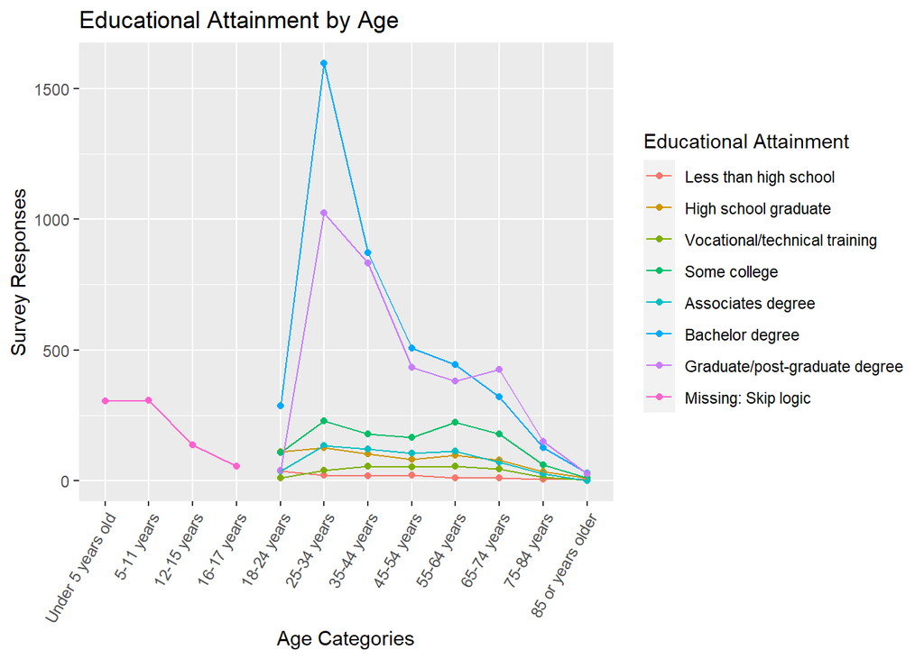

|  | Less than high school (N=114) | High school graduate (N=507) | Vocational/technical training (N=218) | Some college (N=836) | Associates degree (N=399) | Bachelor degree (N=2727) | Graduate/post-graduate degree (N=1518) | Overall (N=6319) |
| --- | --- | --- | --- | --- | --- | --- | --- | --- |
| as.factor(vehicle_group) |  |  |  |  |  |  |  |  |
| 0 | 23 (20.2%) | 91 (17.9%) | 28 (12.8%) | 168 (20.1%) | 64 (16.0%) | 481 (17.6%) | 256 (16.9%) | 1111 (17.6%) |
| 1 | 31 (27.2%) | 163 (32.1%) | 73 (33.5%) | 339 (40.6%) | 171 (42.9%) | 1394 (51.1%) | 862 (56.8%) | 3033 (48.0%) |
| 2 | 40 (35.1%) | 163 (32.1%) | 77 (35.3%) | 226 (27.0%) | 117 (29.3%) | 716 (26.3%) | 342 (22.5%) | 1681 (26.6%) |
| 3 | 20 (17.5%) | 90 (17.8%) | 40 (18.3%) | 103 (12.3%) | 47 (11.8%) | 136 (5.0%) | 58 (3.8%) | 494 (7.8%) |

Because individuals with **`Vocational/technical training`** are more likely to have jobs in the specific service professions, this may necessitate the need for a vehicle. Further investigation into vehicle for this subset of the households reveals that households with vocational/technical training make up the highest proportion of households with 2 vehicles (35%) and 3 vehicles (18%). It is important to note that the sample size of households with `Vocational/technical training` as minimum educational attainment represents only 3.4% of the total number of households surveyed.

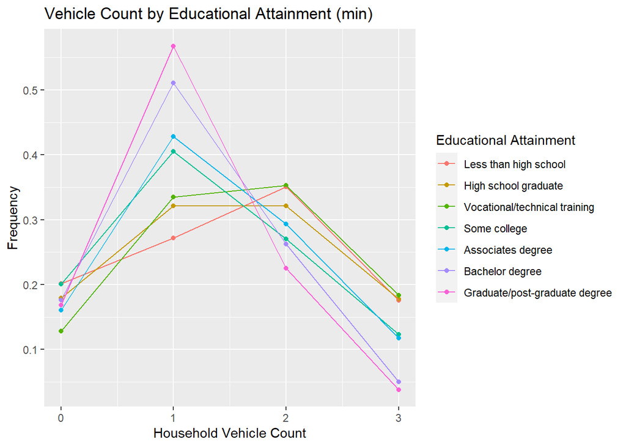

The following table provides more detailed information into the relationship between education and a more standardized vehicle count value (**number of household vehicles*/*number of household workers**). Higher values indicate that the households own more vehicles per number of household workers.

|  | Less than high school (N=114) | High school graduate (N=507) | Vocational/technical training (N=218) | Some college (N=836) | Associates degree (N=399) | Bachelor degree (N=2727) | Graduate/post-graduate degree (N=1518) | Overall (N=6319) |
| --- | --- | --- | --- | --- | --- | --- | --- | --- |
| veh_numworkers |  |  |  |  |  |  |  |  |
| Mean (SD) | 0.628 (0.497) | 0.733 (0.612) | 0.807 (0.600) | 0.707 (0.619) | 0.712 (0.570) | 0.568 (0.457) | 0.599 (0.495) | 0.626 (0.522) |
| Median [Min, Max] | 0.583 [0, 2.00] | 0.667 [0, 3.00] | 0.667 [0, 3.00] | 0.583 [0, 3.00] | 0.667 [0, 3.00] | 0.500 [0, 3.00] | 0.500 [0, 3.00] | 0.500 [0, 3.00] |

This table reveals that almost all households, regardless of minimum education level, own a range of 0-3+ vehicles. Despite this, households with a member holding a vocational/technical degree own the highest average number of vehicles when considering the number of household workers.

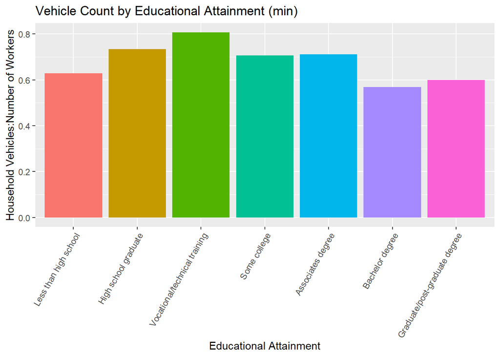

###### *Household education maximum*

Margin of Error

| education_max | Percentage_0 | Percentage_1 | Percentage_2 | Percentage_3 | Total_0 | Total_1 | Total_2 | Total_3 | Count_0 | Count_1 | Count_2 | Count_3 | sample_size | MOE_Percent |
| --- | --- | --- | --- | --- | --- | --- | --- | --- | --- | --- | --- | --- | --- | --- |
| Less than high school | 59.821633 | 33.71758 | 6.460788 | NA | 2362.731 | 1331.719 | 255.177 | NA | 9 | 9 | 2 | NA | 20 | 18.391659 |
| High school graduate | 18.089293 | 38.72179 | 30.918140 | 12.27077 | 13744.039 | 29420.378 | 23491.251 | 9323.194 | 65 | 69 | 41 | 12 | 187 | 6.014716 |
| Vocational/technical training | 8.665592 | 29.50944 | 43.864340 | 17.96062 | 2694.832 | 9176.869 | 13640.965 | 5585.408 | 23 | 41 | 24 | 6 | 94 | 8.483440 |
| Some college | 15.263581 | 37.24064 | 28.348049 | 19.14773 | 33415.808 | 81529.108 | 62060.991 | 41919.180 | 162 | 257 | 117 | 57 | 593 | 3.377603 |
| Associates degree | 7.523558 | 33.10337 | 28.011634 | 31.36144 | 10146.166 | 44642.744 | 37776.099 | 42293.598 | 63 | 146 | 80 | 48 | 337 | 4.480443 |
| Bachelor degree | 5.734550 | 33.70894 | 33.548157 | 27.00835 | 33313.509 | 195824.125 | 194890.080 | 156898.626 | 461 | 1253 | 601 | 180 | 2495 | 1.646647 |
| Graduate/post-graduate degree | 5.567242 | 24.64086 | 47.918396 | 21.87351 | 34016.898 | 150560.260 | 292790.408 | 133651.236 | 328 | 1258 | 816 | 191 | 2593 | 1.615231 |

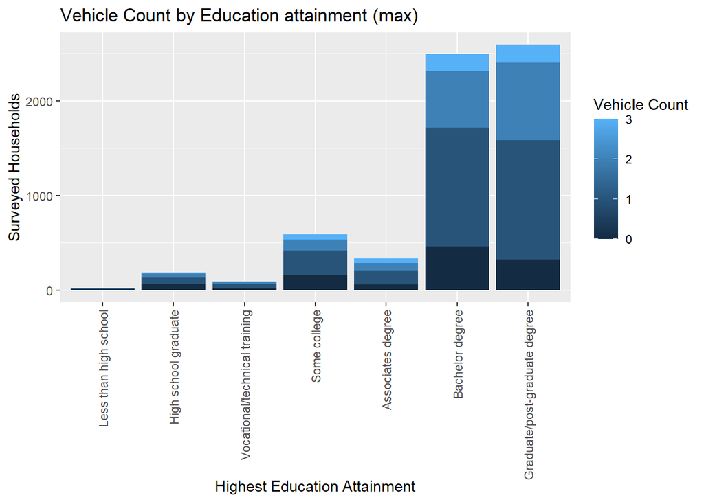

Reference group: Less than high school

```
##                                            Value Std. Error t value
## explanatoryHigh school graduate           0.7687     0.4461  1.7230
## explanatoryVocational/technical training  1.1549     0.4660  2.4783
## explanatorySome college                   1.0424     0.4297  2.4259
## explanatoryAssociates degree              1.5608     0.4353  3.5854
## explanatoryBachelor degree                1.2969     0.4240  3.0590
## explanatoryGraduate/post-graduate degree  1.6214     0.4240  3.8240
## 0|1                                      -0.1595     0.4221 -0.3778
## 1|2                                       2.0596     0.4230  4.8691
## 2|3                                       3.8914     0.4250  9.1565
##                                               p-value simp p. odds ratio
## explanatoryHigh school graduate          8.489651e-02  0.0849     2.1569
## explanatoryVocational/technical training 1.320125e-02  0.0132     3.1738
## explanatorySome college                  1.527248e-02  0.0153     2.8360
## explanatoryAssociates degree             3.365992e-04  0.0003     4.7627
## explanatoryBachelor degree               2.221026e-03  0.0022     3.6580
## explanatoryGraduate/post-graduate degree 1.313235e-04  0.0001     5.0603
## 0|1                                      7.055971e-01  0.7056     2.1569
## 1|2                                      1.121222e-06  0.0000     3.1738
## 2|3                                      5.362642e-20  0.0000     2.8360
```

**Vehicle Count by Highest educational attainment**

|  | *Dependent variable:* |
| --- | --- |
|  | outcome |
| explanatoryHigh school graduate | 0.769* |
|  | (0.446) |
| explanatoryVocational/technical training | 1.155** |
|  | (0.466) |
| explanatorySome college | 1.042** |
|  | (0.430) |
| explanatoryAssociates degree | 1.561*** |
|  | (0.435) |
| explanatoryBachelor degree | 1.297*** |
|  | (0.424) |
| explanatoryGraduate/post-graduate degree | 1.621*** |
|  | (0.424) |
| Observations | 6,319 |
| *Note:* | <sup>⋆</sup>p<0.1; <sup>⋆⋆</sup>p<0.05; <sup>⋆⋆⋆</sup>p<0.01 |

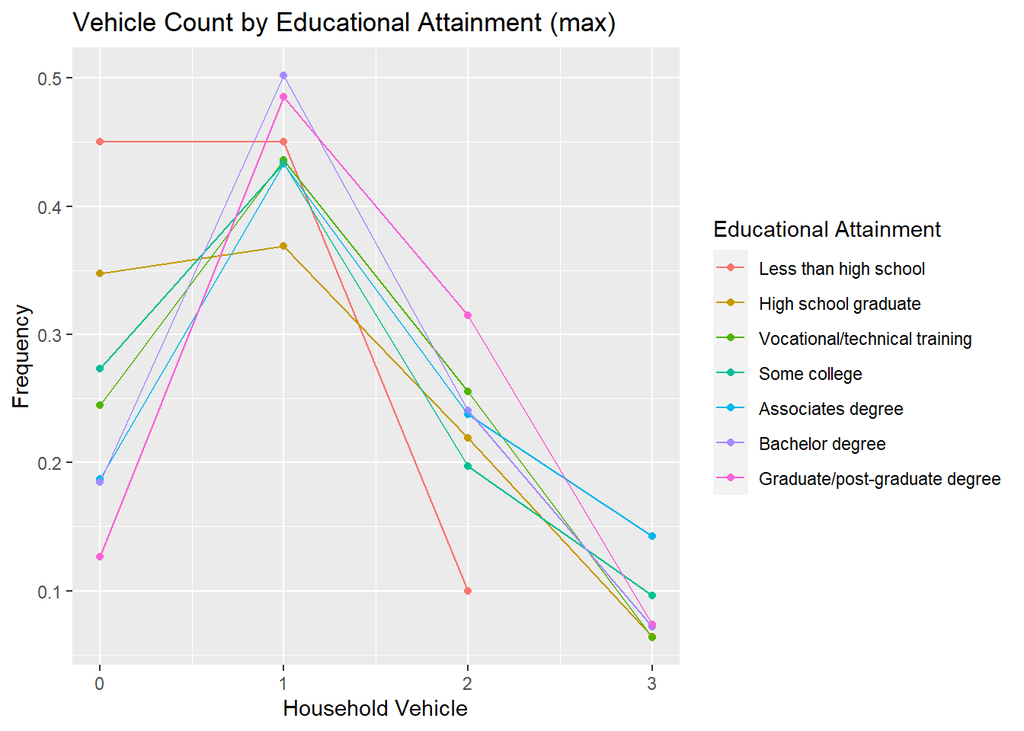

The following table provides more detailed information into the relationship between education and a more standardized vehicle count value (**number of household vehicles*/*number of household workers**). Higher values indicate that the households own more vehicles per number of household workers.

|  | Less than high school (N=20) | High school graduate (N=187) | Vocational/technical training (N=94) | Some college (N=593) | Associates degree (N=337) | Bachelor degree (N=2495) | Graduate/post-graduate degree (N=2593) | Overall (N=6319) |
| --- | --- | --- | --- | --- | --- | --- | --- | --- |
| veh_numworkers |  |  |  |  |  |  |  |  |
| Mean (SD) | 0.350 (0.486) | 0.611 (0.655) | 0.637 (0.520) | 0.634 (0.586) | 0.716 (0.591) | 0.580 (0.478) | 0.658 (0.522) | 0.626 (0.522) |
| Median [Min, Max] | 0.250 [0, 2.00] | 0.500 [0, 3.00] | 0.500 [0, 2.00] | 0.500 [0, 3.00] | 0.667 [0, 3.00] | 0.500 [0, 3.00] | 0.500 [0, 3.00] | 0.500 [0, 3.00] |

This table reveals that most households, regardless of maximum education level, own a range of 0-3+ vehicles. Households with a member holding an associates degree as the highest educational attainment own the highest average number of vehicles when considering the number of household workers. Households with a member having less than a high school degree as the highest educational attainment own the fewest vehicles per number of workers. It is important to note that the standard deviations are relatively high.

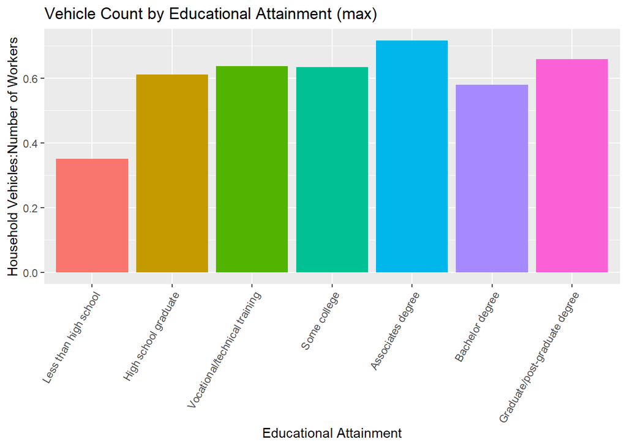

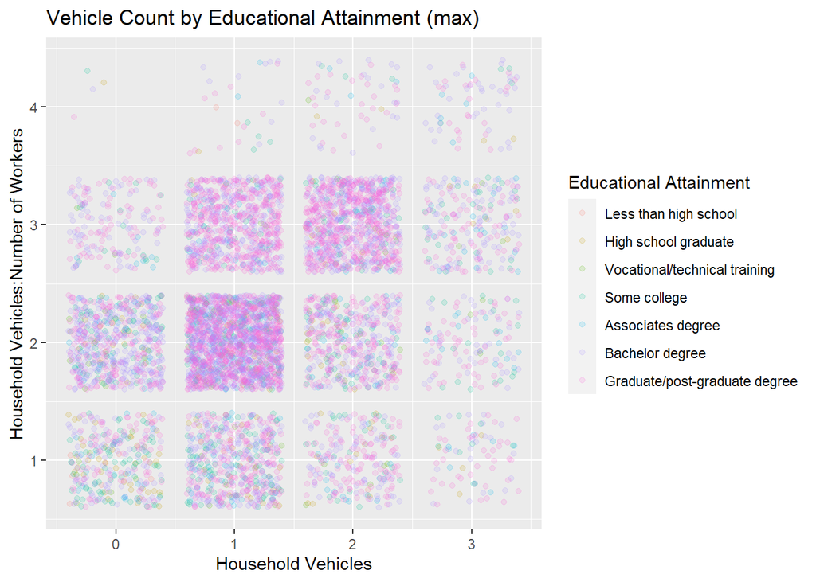

##### *Simplified education categories*

These education attainment categories have been simplified into the following 4 categories:

- high school or less
- vocational, associates, less than 4 years of college
- bachelor degree
- post-graduate

**Lowest Simplified Educational Attainment**

```
## Frequencies
## person_and_household$hh_edu_min_simp
## Type: Factor
##
##                          Freq   % Valid   % Valid Cum.   % Total   % Total Cum.
## ---------------------- ------ --------- -------------- --------- --------------
##            High school    621      9.83           9.83      9.83           9.83
##       Specialized, <4y   1453     22.99          32.82     22.99          32.82
##        Bachelor degree   2727     43.16          75.98     43.16          75.98
##          Post-graduate   1518     24.02         100.00     24.02         100.00
##                   <NA>      0                               0.00         100.00
##                  Total   6319    100.00         100.00    100.00         100.00
```

**Highest Simplified Educational Attainment**

```
## Frequencies
## person_and_household$hh_edu_max_simp
## Type: Factor
##
##                          Freq   % Valid   % Valid Cum.   % Total   % Total Cum.
## ---------------------- ------ --------- -------------- --------- --------------
##            High school    207      3.28           3.28      3.28           3.28
##       Specialized, <4y   1024     16.21          19.48     16.21          19.48
##        Bachelor degree   2495     39.48          58.97     39.48          58.97
##          Post-graduate   2593     41.03         100.00     41.03         100.00
##                   <NA>      0                               0.00         100.00
##                  Total   6319    100.00         100.00    100.00         100.00
```

###### *Simp. household education minimum*

Margin of Error

| hh_edu_min_simp | Percentage_0 | Percentage_1 | Percentage_2 | Percentage_3 | Total_0 | Total_1 | Total_2 | Total_3 | Count_0 | Count_1 | Count_2 | Count_3 | sample_size | MOE_Percent |
| --- | --- | --- | --- | --- | --- | --- | --- | --- | --- | --- | --- | --- | --- | --- |
| High school | 7.255363 | 20.54531 | 36.82640 | 35.37293 | 25151.04 | 71221.23 | 127660.35 | 122621.84 | 114 | 194 | 203 | 110 | 621 | 3.300579 |
| Specialized, <4y | 7.483865 | 28.67105 | 33.39559 | 30.44949 | 40454.49 | 154983.13 | 180521.91 | 164596.62 | 260 | 583 | 420 | 190 | 1453 | 2.157760 |
| Bachelor degree | 6.794764 | 34.20082 | 45.34123 | 13.66319 | 34167.62 | 171979.57 | 227999.38 | 68705.66 | 481 | 1394 | 716 | 136 | 2727 | 1.575046 |
| Post-graduate | 11.219221 | 42.85882 | 33.26802 | 12.65395 | 29920.83 | 114301.27 | 88723.33 | 33747.13 | 256 | 862 | 342 | 58 | 1518 | 2.111057 |

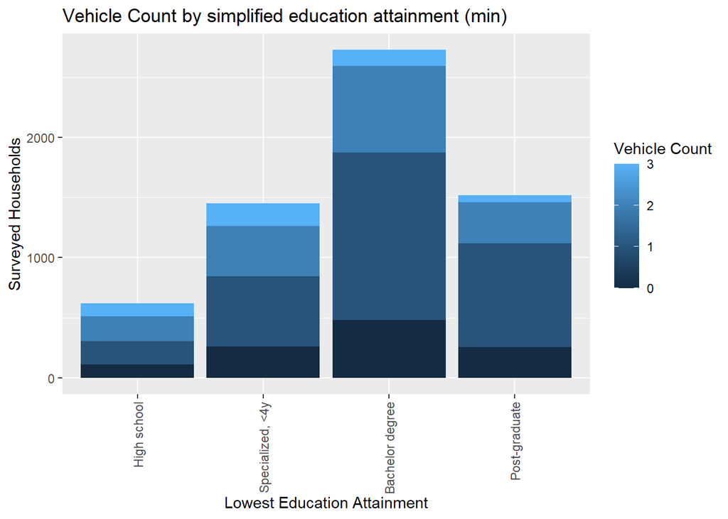

Reference group: High school

```
##                               Value Std. Error  t value       p-value simp p.
## explanatorySpecialized, <4y -0.3096     0.0932  -3.3222  8.930803e-04  0.0009
## explanatoryBachelor degree  -0.6944     0.0864  -8.0363  9.257767e-16  0.0000
## explanatoryPost-graduate    -0.8095     0.0918  -8.8142  1.205219e-18  0.0000
## 0|1                         -2.1424     0.0838 -25.5607 4.172643e-144  0.0000
## 1|2                          0.0710     0.0792   0.8961  3.701986e-01  0.3702
## 2|3                          1.9235     0.0857  22.4373 1.703104e-111  0.0000
##                             odds ratio
## explanatorySpecialized, <4y     0.7337
## explanatoryBachelor degree      0.4994
## explanatoryPost-graduate        0.4451
## 0|1                             0.7337
## 1|2                             0.4994
## 2|3                             0.4451
```

**Vehicle Count by Lowest educational attainment (simplified)**

|  | *Dependent variable:* |
| --- | --- |
|  | outcome |
| explanatorySpecialized, < 4y | -0.310*** |
|  | (0.093) |
| explanatoryBachelor degree | -0.694*** |
|  | (0.086) |
| explanatoryPost-graduate | -0.809*** |
|  | (0.092) |
| Observations | 6,319 |
| *Note:* | <sup>⋆</sup>p<0.1; <sup>⋆⋆</sup>p<0.05; <sup>⋆⋆⋆</sup>p<0.01 |

In reference to the households with a high school degree as the lowest educational attainment, households with more education (post-graduate) are less likely to own more vehicles, while those with less education are more likely to own more vehicles. This negative association between educational attainment (min) and household vehicle count is statistically significant.

###### *Simp. household education maximum*

Margin of Error

| hh_edu_max_simp | Percentage_0 | Percentage_1 | Percentage_2 | Percentage_3 | Total_0 | Total_1 | Total_2 | Total_3 | Count_0 | Count_1 | Count_2 | Count_3 | sample_size | MOE_Percent |
| --- | --- | --- | --- | --- | --- | --- | --- | --- | --- | --- | --- | --- | --- | --- |
| High school | 20.151476 | 38.47451 | 29.70959 | 11.66442 | 16106.77 | 30752.1 | 23746.43 | 9323.194 | 74 | 78 | 43 | 12 | 207 | 5.716770 |
| Specialized, <4y | 12.018446 | 35.16631 | 29.48387 | 23.33137 | 46256.81 | 135348.7 | 113478.05 | 89798.186 | 248 | 444 | 221 | 111 | 1024 | 2.570312 |
| Bachelor degree | 5.734550 | 33.70894 | 33.54816 | 27.00835 | 33313.51 | 195824.1 | 194890.08 | 156898.626 | 461 | 1253 | 601 | 180 | 2495 | 1.646647 |
| Post-graduate | 5.567242 | 24.64086 | 47.91840 | 21.87351 | 34016.90 | 150560.3 | 292790.41 | 133651.236 | 328 | 1258 | 816 | 191 | 2593 | 1.615231 |

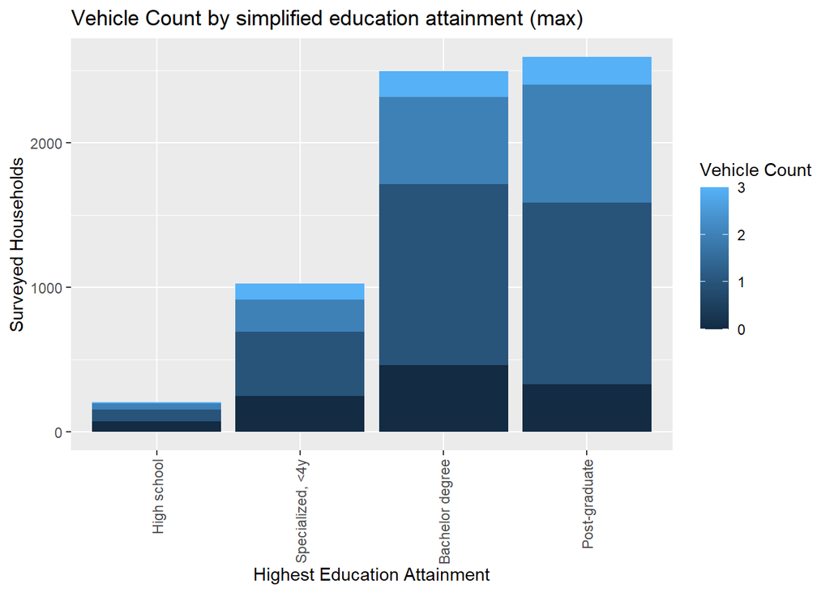

Reference group: High school

```
##                               Value Std. Error t value       p-value simp p.
## explanatorySpecialized, <4y  0.5358     0.1496  3.5809  3.424778e-04   3e-04
## explanatoryBachelor degree   0.6085     0.1419  4.2891  1.793880e-05   0e+00
## explanatoryPost-graduate     0.9323     0.1418  6.5758  4.838083e-11   0e+00
## 0|1                         -0.8447     0.1374 -6.1497  7.760941e-10   0e+00
## 1|2                          1.3695     0.1383  9.9054  3.942379e-23   0e+00
## 2|3                          3.1994     0.1440 22.2179 2.305857e-109   0e+00
##                             odds ratio
## explanatorySpecialized, <4y     1.7088
## explanatoryBachelor degree      1.8376
## explanatoryPost-graduate        2.5404
## 0|1                             1.7088
## 1|2                             1.8376
## 2|3                             2.5404
```

**Vehicle Count by Highest educational attainment (simplified)**

|  | *Dependent variable:* |
| --- | --- |
|  | outcome |
| explanatorySpecialized, < 4y | 0.536*** |
|  | (0.150) |
| explanatoryBachelor degree | 0.608*** |
|  | (0.142) |
| explanatoryPost-graduate | 0.932*** |
|  | (0.142) |
| Observations | 6,319 |
| *Note:* | <sup>⋆</sup>p<0.1; <sup>⋆⋆</sup>p<0.05; <sup>⋆⋆⋆</sup>p<0.01 |

In reference to the households with a high school degree as the highest educational attainment, households with more education (post-graduate) are more likely to own more vehicles, while those with high school or less are less likely to own more vehicles. This positive association between educational attainment (max) and household vehicle count is statistically significant.

#### *8. Race*

The household travel survey asked participants about the race of adults in each household, with no children in households assigned to any racial group.  
Original data at a person level (11,940 survey respondents).

|  | Overall (N=11940) |
| --- | --- |
| race_category |  |
| African American | 257 (2%) |
| Asian | 1513 (13%) |
| Child | 1650 (14%) |
| Hispanic | 380 (3%) |
| Missing | 690 (6%) |
| Other | 443 (4%) |
| White Only | 7007 (59%) |

The person level race data is aggregated to the household level (6,319) based on the following logic:

1. Households were grouped into single racial groups alone based on the identified race of the individual members (i.e. African American alone, Asian alone, Hispanic alone, etc.), as well as a category for households with members of different races

   |  | Overall (N=6319) |
   | --- | --- |
   | hh_race_category |  |
   | African American | 185 (3%) |
   | Asian | 1024 (16%) |
   | Hispanic | 282 (4%) |
   | Missing | 427 (7%) |
   | Other | 400 (6%) |
   | White Only | 4001 (63%) |

2. Other than Asian and Non-Hispanic White, the groups were too small to report, and were therefore combined together into categories large enough to achieve statistically valid sample sizes. Survey participants could choose not to select any choice for race; households with any adults missing race were assigned to a Missing group. The “Missing/Other” group includes households categorized as “Missing” or “Other.”

Three groups are shown in the analysis below:

- A composite of households where all adults are African American, Hispanic, or Native American, and households with non-White adults of multiple races
- Households where all adults are Asian alone
- Households where all adults are Non-Hispanic White alone

##### *White Only, Asian, and other POC households*

White only (7,147), Asian (2,141), other POC (935), and missing/other (1,717).

| hh_race_3 | Percentage_0 | Percentage_1 | Percentage_2 | Percentage_3 | Total_0 | Total_1 | Total_2 | Total_3 | Count_0 | Count_1 | Count_2 | Count_3 | sample_size | MOE_Percent |
| --- | --- | --- | --- | --- | --- | --- | --- | --- | --- | --- | --- | --- | --- | --- |
| Asian | 10.901398 | 33.87965 | 42.60974 | 12.60921 | 21070.38 | 65483.07 | 82356.72 | 24371.27 | 195 | 499 | 275 | 55 | 1024 | 2.570312 |
| Missing/Other | 5.480810 | 34.71955 | 36.13132 | 23.66832 | 25865.91 | 163854.03 | 170516.69 | 111699.34 | 145 | 379 | 227 | 76 | 827 | 2.860113 |
| People of Color | 12.503948 | 40.72706 | 31.67759 | 15.09140 | 28982.44 | 94399.75 | 73424.31 | 34979.81 | 96 | 218 | 120 | 33 | 467 | 3.806076 |
| White Only | 7.078003 | 24.84343 | 39.30327 | 28.77530 | 53775.25 | 188748.36 | 298607.25 | 218620.83 | 675 | 1937 | 1059 | 330 | 4001 | 1.300324 |

Reference group: White Only

```
##                              Value Std. Error  t value      p-value simp p.
## explanatoryPeople of Color -0.1504     0.0918  -1.6382 1.013788e-01  0.1014
## explanatoryAsian           -0.1469     0.0650  -2.2596 2.384654e-02  0.0238
## explanatoryMissing/Other    0.0471     0.0715   0.6586 5.101782e-01  0.5102
## 0|1                        -1.5752     0.0377 -41.7451 0.000000e+00  0.0000
## 1|2                         0.6162     0.0318  19.3730 1.304973e-83  0.0000
## 2|3                         2.4401     0.0500  48.8000 0.000000e+00  0.0000
##                            odds ratio
## explanatoryPeople of Color     0.8603
## explanatoryAsian               0.8634
## explanatoryMissing/Other       1.0482
## 0|1                            0.8603
## 1|2                            0.8634
## 2|3                            1.0482
```

**Vehicle Count by Race**

|  | *Dependent variable:* |
| --- | --- |
|  | outcome |
| explanatoryPeople of Color | -0.150 |
|  | (0.092) |
| explanatoryAsian | -0.147** |
|  | (0.065) |
| explanatoryMissing/Other | 0.047 |
|  | (0.072) |
| Observations | 6,319 |
| *Note:* | <sup>⋆</sup>p<0.1; <sup>⋆⋆</sup>p<0.05; <sup>⋆⋆⋆</sup>p<0.01 |

The relationship between race and household vehicle count is statistically significant for Asian households. POC households show a similar trend - owning fewer vehicles than white households - but the relationship is not significant. This is likely because of the small sample size of POC households, excluding Asian households (less than 10% of the sample: 467/6,319). This indicates that the White Only and POC household analysis is largely based on Asian households (~16%: 1,024/6,319).

##### *Alternative: White Only and POC households*

Because of the small numbers of respondents identifying as non-white, these groups have been grouped together as “POC” - including households with individuals who identified as “African American,” “Asian”, and “Hispanic.”

|  | Overall (N=6319) |
| --- | --- |
| hh_race_2 |  |
| Missing/Other | 827 (13%) |
| People of Color | 1491 (24%) |
| White Only | 4001 (63%) |

| hh_race_2 | Percentage_0 | Percentage_1 | Percentage_2 | Percentage_3 | Total_0 | Total_1 | Total_2 | Total_3 | Count_0 | Count_1 | Count_2 | Count_3 | sample_size | MOE_Percent |
| --- | --- | --- | --- | --- | --- | --- | --- | --- | --- | --- | --- | --- | --- | --- |
| Missing/Other | 5.480810 | 34.71955 | 36.13132 | 23.66832 | 25865.91 | 163854.0 | 170516.7 | 111699.34 | 145 | 379 | 227 | 76 | 827 | 2.860113 |
| People of Color | 11.775257 | 37.61349 | 36.64852 | 13.96273 | 50052.82 | 159882.8 | 155781.0 | 59351.07 | 291 | 717 | 395 | 88 | 1491 | 2.130086 |
| White Only | 7.078003 | 24.84343 | 39.30327 | 28.77530 | 53775.25 | 188748.4 | 298607.2 | 218620.83 | 675 | 1937 | 1059 | 330 | 4001 | 1.300324 |

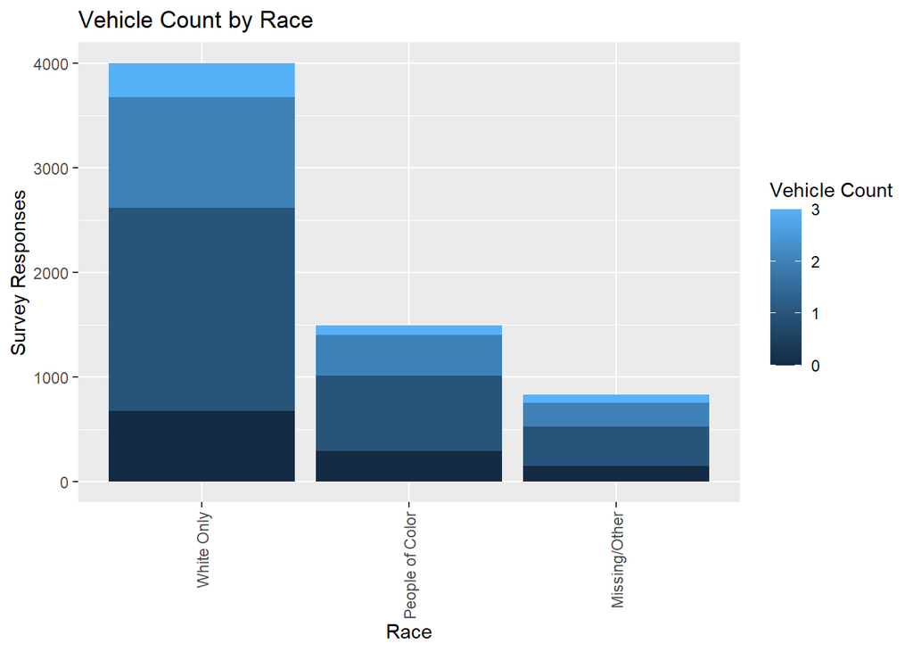

Reference group: White Only

```
##                              Value Std. Error  t value      p-value simp p.
## explanatoryPeople of Color -0.1480     0.0565  -2.6186 8.829566e-03  0.0088
## explanatoryMissing/Other    0.0471     0.0715   0.6587 5.100699e-01  0.5101
## 0|1                        -1.5752     0.0377 -41.7457 0.000000e+00  0.0000
## 1|2                         0.6162     0.0318  19.3721 1.327789e-83  0.0000
## 2|3                         2.4401     0.0500  48.7996 0.000000e+00  0.0000
##                            odds ratio
## explanatoryPeople of Color     0.8624
## explanatoryMissing/Other       1.0482
## 0|1                            0.8624
## 1|2                            1.0482
## 2|3                            0.8624
```

**Vehicle Count by Race**

|  | *Dependent variable:* |
| --- | --- |
|  | outcome |
| explanatoryPeople of Color | -0.148*** |
|  | (0.057) |
| explanatoryMissing/Other | 0.047 |
|  | (0.072) |
| Observations | 6,319 |
| *Note:* | <sup>⋆</sup>p<0.1; <sup>⋆⋆</sup>p<0.05; <sup>⋆⋆⋆</sup>p<0.01 |

The relationship between race and household vehicle count is statistically significant with POC households owning fewer vehicles.

#### *9. Housing*

This category can be analyzed at two different levels:

- housing tenure (rent vs. own)
- residential type

##### *Housing tenure*

|  | Overall (N=6319) |
| --- | --- |
| rent_own |  |
| Other | 71 (1%) |
| Own/paying mortgage | 3011 (48%) |
| Prefer not to answer | 68 (1%) |
| Provided by job or military | 21 (0%) |
| Rent | 3148 (50%) |

Because the majority of respondents identify as renters or owners, the other categories with fewer responses were grouped together.

|  | Overall (N=6319) |
| --- | --- |
| rent_own_simp |  |
| Own/paying mortgage | 3011 (48%) |
| Rent | 3148 (50%) |
| Other | 160 (3%) |

**Vehicle count by housing tenure - survey sample**

|  | 0 (N=1111) | 1 (N=3033) | 2 (N=1681) | 3 (N=494) | Overall (N=6319) |
| --- | --- | --- | --- | --- | --- |
| rent_own_simp |  |  |  |  |  |
| Own/paying mortgage | 149 (13.4%) | 1274 (42.0%) | 1168 (69.5%) | 420 (85.0%) | 3011 (47.6%) |
| Rent | 933 (84.0%) | 1693 (55.8%) | 461 (27.4%) | 61 (12.3%) | 3148 (49.8%) |
| Other | 29 (2.6%) | 66 (2.2%) | 52 (3.1%) | 13 (2.6%) | 160 (2.5%) |

**Vehicle count by housing tenure - region (weighted)**

| rent_own_simp | Percentage_0 | Percentage_1 | Percentage_2 | Percentage_3 | Total_0 | Total_1 | Total_2 | Total_3 | Count_0 | Count_1 | Count_2 | Count_3 | sample_size | MOE_Percent |
| --- | --- | --- | --- | --- | --- | --- | --- | --- | --- | --- | --- | --- | --- | --- |
| Other | 7.318935 | 42.72362 | 39.72540 | 10.232039 | 6352.305 | 37081.0 | 34478.76 | 8880.668 | 29 | 66 | 52 | 13 | 160 | 6.502433 |
| Own/paying mortgage | 1.273685 | 21.79471 | 43.90040 | 33.031205 | 13283.330 | 227298.1 | 457839.60 | 344484.166 | 149 | 1274 | 1168 | 420 | 3011 | 1.498927 |
| Rent | 20.881661 | 47.07382 | 25.15601 | 6.888511 | 110058.348 | 248106.1 | 132586.60 | 36306.408 | 933 | 1693 | 461 | 61 | 3148 | 1.465948 |

**Survey Responses**

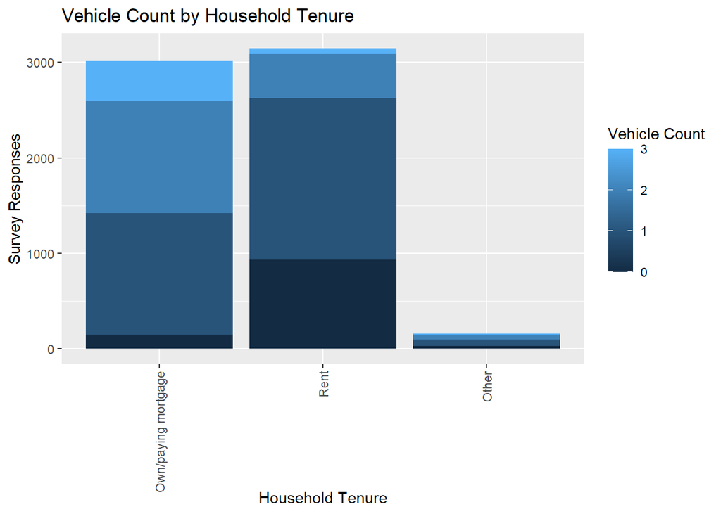

**Region (weighted)**

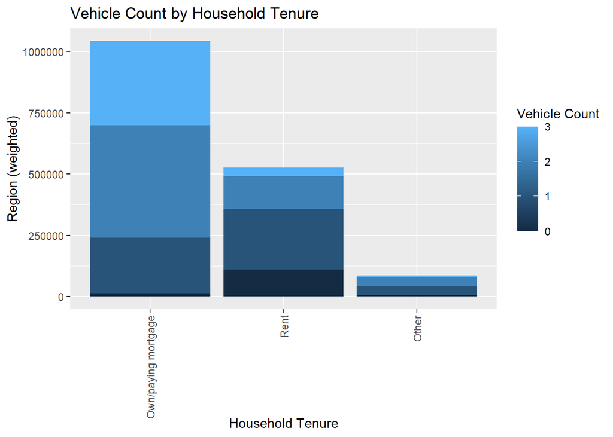

Reference group: Own/paying mortgage

```
##                    Value Std. Error  t value       p-value simp p. odds ratio
## explanatoryRent  -1.8295     0.0544 -33.6513 2.987023e-248       0     0.1605
## explanatoryOther -0.7179     0.1592  -4.5107  6.461042e-06       0     0.4878
## 0|1              -2.7239     0.0521 -52.3176  0.000000e+00       0     0.1605
## 1|2              -0.1491     0.0355  -4.1987  2.684942e-05       0     0.4878
## 2|3               1.8552     0.0498  37.2417 1.446079e-303       0     0.1605
```

**Vehicle Count by Household Tenure**

|  | *Dependent variable:* |
| --- | --- |
|  | outcome |
| explanatoryRent | -1.829*** |
|  | (0.054) |
| explanatoryOther | -0.718*** |
|  | (0.159) |
| Observations | 6,319 |
| *Note:* | <sup>⋆</sup>p<0.1; <sup>⋆⋆</sup>p<0.05; <sup>⋆⋆⋆</sup>p<0.01 |

The relationship between household tenure and household vehicle count is statistically significant, with renting individuals reporting that they are part of households that own fewer vehicles.

##### *Housing type*

|  | Overall (N=6319) |
| --- | --- |
| res_type |  |
| Building with 3 or fewer apartments/condos | 195 (3%) |
| Building with 4 or more apartments/condos | 3390 (54%) |
| Dorm or institutional housing | 24 (0%) |
| Mobile home/trailer | 39 (1%) |
| Other (including boat, RV, van, etc.) | 17 (0%) |
| Single-family house (detached house) | 2120 (34%) |
| Townhouse (attached house) | 534 (8%) |

Because the majority of respondents identify as living in apartment buildings or single-family detached houses, the survey responses have been simplified and recategorized.

|  | Overall (N=6319) |
| --- | --- |
| restype_simp |  |
| Apartment/condo | 3585 (57%) |
| Other | 80 (1%) |
| Single-family | 2120 (34%) |
| Townhouse | 534 (8%) |

| restype_simp | Percentage_0 | Percentage_1 | Percentage_2 | Percentage_3 | Total_0 | Total_1 | Total_2 | Total_3 | Count_0 | Count_1 | Count_2 | Count_3 | sample_size | MOE_Percent |
| --- | --- | --- | --- | --- | --- | --- | --- | --- | --- | --- | --- | --- | --- | --- |
| Apartment/condo | 21.870412 | 55.82154 | 21.32350 | 0.9845535 | 107501.116 | 274383.38 | 104812.830 | 4839.442 | 1000 | 2043 | 500 | 42 | 3585 | 1.373698 |
| Other | 5.805563 | 44.04021 | 18.48334 | 31.6708857 | 2091.389 | 15864.99 | 6658.415 | 11409.081 | 20 | 39 | 15 | 6 | 80 | 9.195830 |
| Single-family | 1.741326 | 17.60522 | 45.43883 | 35.2146264 | 17527.974 | 177211.92 | 457381.597 | 354466.039 | 57 | 650 | 995 | 418 | 2120 | 1.786356 |
| Townhouse | 2.098983 | 36.72289 | 45.71682 | 15.4613076 | 2573.504 | 45024.91 | 56052.127 | 18956.680 | 34 | 301 | 171 | 28 | 534 | 3.559306 |

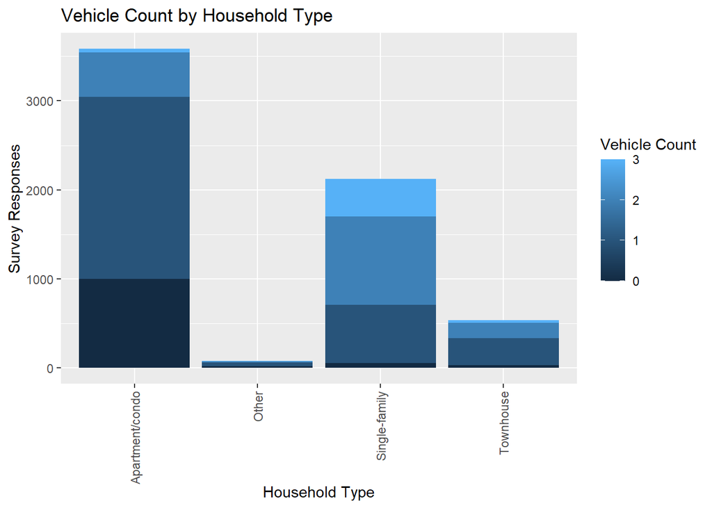

Reference group: Apartment/condo

```
##                            Value Std. Error  t value       p-value simp p.
## explanatoryOther          0.4782     0.2329   2.0532  4.005526e-02  0.0401
## explanatorySingle-family  2.5100     0.0618  40.6324  0.000000e+00  0.0000
## explanatoryTownhouse      1.3146     0.0900  14.6121  2.351416e-48  0.0000
## 0|1                      -0.9677     0.0364 -26.5962 7.501199e-156  0.0000
## 1|2                       1.7706     0.0442  40.0980  0.000000e+00  0.0000
## 2|3                       3.9820     0.0659  60.3956  0.000000e+00  0.0000
##                          odds ratio
## explanatoryOther             1.6132
## explanatorySingle-family    12.3055
## explanatoryTownhouse         3.7232
## 0|1                          1.6132
## 1|2                         12.3055
## 2|3                          3.7232
```

**Vehicle Count by Household Type**

|  | *Dependent variable:* |
| --- | --- |
|  | outcome |
| explanatoryOther | 0.478** |
|  | (0.233) |
| explanatorySingle-family | 2.510*** |
|  | (0.062) |
| explanatoryTownhouse | 1.315*** |
|  | (0.090) |
| Observations | 6,319 |
| *Note:* | <sup>⋆</sup>p<0.1; <sup>⋆⋆</sup>p<0.05; <sup>⋆⋆⋆</sup>p<0.01 |

The relationship between household type and household vehicle counts is statistically significant, with single-family (detached) households reporting highest vehicle counts. Households in townhomes (attached) report higher vehicle counts than those in apartments or condos, but lower vehicle counts than those in single-family houses.

#### *10. Housing location*

This measurement will analyze housing location in relation to regional growth centers (RGCs). According to PSRC’s VISION 2050 planning process: “The region has designated 29 regional growth centers. These are locations of the region’s most significant business, governmental, and cultural facilities and are planning for growth.” More information is available at https://www.psrc.org/centers.

```
## Frequencies
## person_and_household$final_home_rgcnum
## Type: Character
##
##                                         Freq   % Valid   % Valid Cum.   % Total   % Total Cum.
## ------------------------------------- ------ --------- -------------- --------- --------------
##                                Auburn      4     0.063          0.063     0.063          0.063
##                     Bellevue Downtown      9     0.142          0.206     0.142          0.206
##                   Bothell Canyon Park     10     0.158          0.364     0.158          0.364
##                             Bremerton      7     0.111          0.475     0.111          0.475
##                                Burien     10     0.158          0.633     0.158          0.633
##                               Everett     20     0.317          0.950     0.317          0.950
##                           Federal Way      3     0.047          0.997     0.047          0.997
##                              Issaquah      3     0.047          1.044     0.047          1.044
##                   Kirkland Totem Lake     13     0.206          1.250     0.206          1.250
##                              Lakewood      7     0.111          1.361     0.111          1.361
##                              Lynnwood      8     0.127          1.488     0.127          1.488
##                               Not RCG   4178    66.118         67.606    66.118         67.606
##                     Puyallup Downtown      4     0.063         67.669     0.063         67.669
##                   Puyallup South Hill     14     0.222         67.890     0.222         67.890
##                      Redmond Downtown    180     2.849         70.739     2.849         70.739
##                      Redmond Overlake     18     0.285         71.024     0.285         71.024
##                                Renton     12     0.190         71.214     0.190         71.214
##                                SeaTac      8     0.127         71.340     0.127         71.340
##                      Seattle Downtown    545     8.625         79.965     8.625         79.965
##       Seattle First Hill/Capitol Hill    530     8.387         88.353     8.387         88.353
##                     Seattle Northgate    111     1.757         90.109     1.757         90.109
##              Seattle South Lake Union    113     1.788         91.897     1.788         91.897
##          Seattle University Community    319     5.048         96.946     5.048         96.946
##                        Seattle Uptown    132     2.089         99.035     2.089         99.035
##                            Silverdale      3     0.047         99.082     0.047         99.082
##                       Tacoma Downtown     36     0.570         99.652     0.570         99.652
##                           Tacoma Mall      6     0.095         99.747     0.095         99.747
##                               Tukwila      2     0.032         99.778     0.032         99.778
##                      University Place     14     0.222        100.000     0.222        100.000
##                                  <NA>      0                              0.000        100.000
##                                 Total   6319   100.000        100.000   100.000        100.000
```

TO simplify analysis, the 29 RGCs are categorized together.

|  | Overall (N=6319) |
| --- | --- |
| RGC_binary |  |
| Not RGC | 4178 (66.1%) |
| RGC | 2141 (33.9%) |

| RGC_binary | Percentage_0 | Percentage_1 | Percentage_2 | Percentage_3 | Total_0 | Total_1 | Total_2 | Total_3 | Count_0 | Count_1 | Count_2 | Count_3 | sample_size | MOE_Percent |
| --- | --- | --- | --- | --- | --- | --- | --- | --- | --- | --- | --- | --- | --- | --- |
| Not RGC | 4.820107 | 29.44523 | 39.58052 | 26.15414 | 70960.61 | 433486.66 | 582696.18 | 385035.910 | 335 | 1975 | 1411 | 457 | 4178 | 1.272482 |
| RGC | 31.820690 | 42.80000 | 22.86797 | 2.51134 | 58733.37 | 78998.55 | 42208.79 | 4635.332 | 776 | 1058 | 270 | 37 | 2141 | 1.777574 |

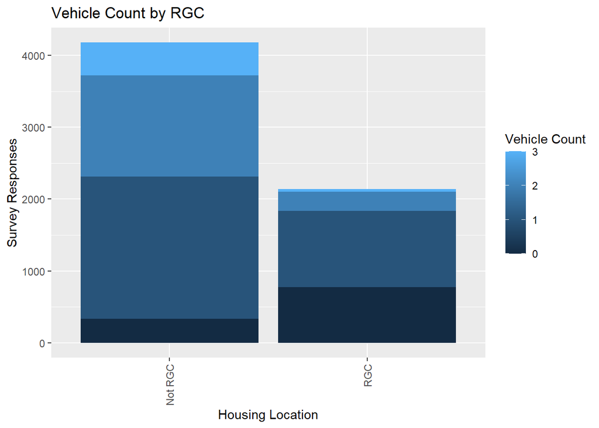

Reference group: Not RGC

```
##                  Value Std. Error  t value       p-value simp p. odds ratio
## explanatoryRGC -1.7305     0.0565 -30.6035 1.098423e-205       0     0.1772
## 0|1            -2.3411     0.0463 -50.5872  0.000000e+00       0     0.1772
## 1|2             0.1878     0.0304   6.1780  6.493273e-10       0     0.1772
## 2|3             2.1148     0.0481  43.9680  0.000000e+00       0     0.1772
```

**Vehicle Count by RGC**

|  | *Dependent variable:* |
| --- | --- |
|  | outcome |
| explanatoryRGC | -1.731*** |
|  | (0.057) |
| Observations | 6,319 |
| *Note:* | <sup>⋆</sup>p<0.1; <sup>⋆⋆</sup>p<0.05; <sup>⋆⋆⋆</sup>p<0.01 |

Households located in RGCs report lower vehicle counts than those living outside of RGCs. This is statistically significant.

#### *11. Commute patterns*

There are 4 commute-related variables. The first three were originally collected at the person level and the last was calculated at the household-level:

- Distance (mi) by automobile
- Time (min) by automobile
- Commute frequency (days/week)
- Number of household commute trips per week

##### *Commute Distance*

Original data at a person level (11,940 survey respondents)

```
##    Min. 1st Qu.  Median    Mean 3rd Qu.    Max.    NA's
##   0.002   1.859   5.043   9.368  11.564 823.767    8650
```

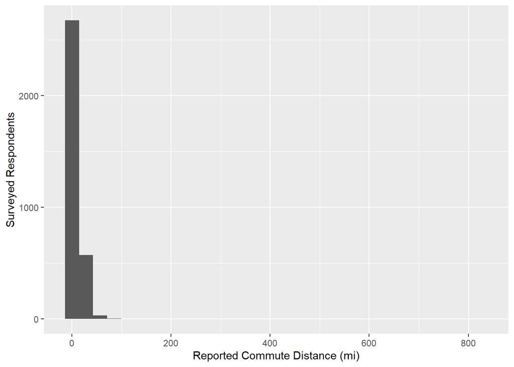

These statistics show outliers within the dataset. **These outliers have not yet been removed.**  
The person level commute distance data is aggregated to the household level (6,319):

- the average commute distance (mi) of the household individuals
- the total commute distance (mi) of the household individuals

###### *Commute distance (average)*

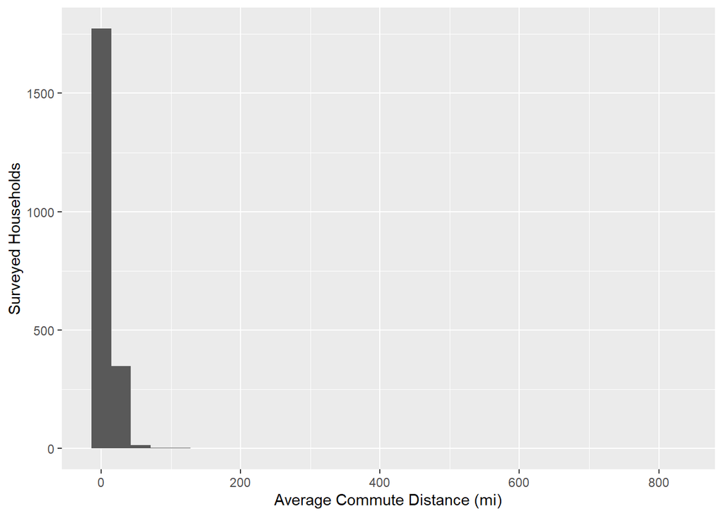

```
##               Value Std. Error  t value       p-value simp p. odds ratio
## explanatory  0.0207     0.0038   5.4362  5.444040e-08       0     1.0209
## 0|1         -1.4223     0.0642 -22.1698 6.721894e-109       0     1.0209
## 1|2          0.7876     0.0577  13.6610  1.736492e-42       0     1.0209
## 2|3          2.5698     0.0876  29.3396 3.247374e-189       0     1.0209
```

**Vehicle Count by Average Commute Distance**

|  | *Dependent variable:* |
| --- | --- |
|  | outcome |
| explanatory | 0.021*** |
|  | (0.004) |
| Observations | 2,145 |
| *Note:* | <sup>⋆</sup>p<0.1; <sup>⋆⋆</sup>p<0.05; <sup>⋆⋆⋆</sup>p<0.01 |

There are fewer observations because of the 4,174 NA values - a result of using the `mean()`.

###### *Commute distance (total)*

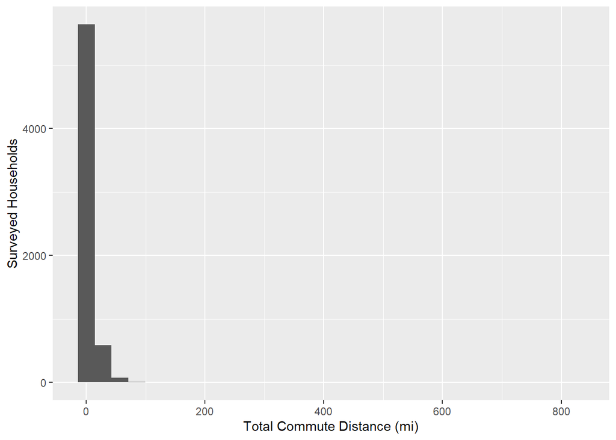

```
##               Value Std. Error  t value       p-value simp p. odds ratio
## explanatory  0.0219     0.0022  10.1304  4.049090e-24       0     1.0222
## 0|1         -1.4661     0.0339 -43.2520  0.000000e+00       0     1.0222
## 1|2          0.7534     0.0287  26.2150 1.791568e-151       0     1.0222
## 2|3          2.6103     0.0496  52.6429  0.000000e+00       0     1.0222
```

**Vehicle Count by Total Commute Distance**

|  | *Dependent variable:* |
| --- | --- |
|  | outcome |
| explanatory | 0.022*** |
|  | (0.002) |
| Observations | 6,319 |
| *Note:* | <sup>⋆</sup>p<0.1; <sup>⋆⋆</sup>p<0.05; <sup>⋆⋆⋆</sup>p<0.01 |

Both average household commute distance and the total household commute distance are positively associated with household vehicle counts. Although the coefficients are small, these variables are statistically significant.

##### *Commute Time*

Original data at a person level (11,940 survey respondents)

```
##    Min. 1st Qu.  Median    Mean 3rd Qu.    Max.    NA's
##   0.000   8.721  16.983  22.002  29.346 837.050    8650
```

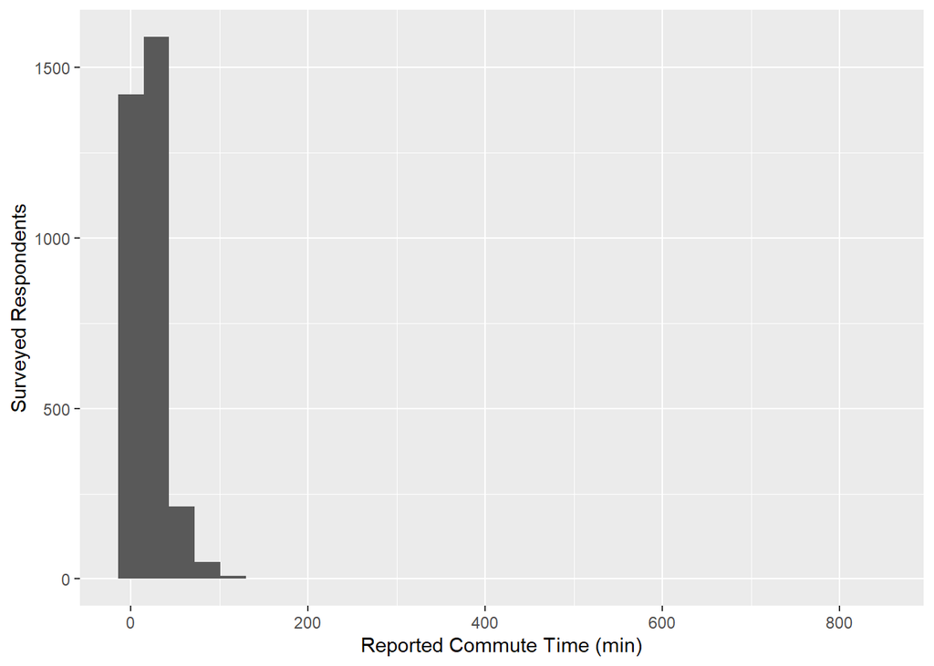

These statistics show outliers within the dataset. **These outliers have not yet been removed.**  
The person level commute distance data is aggregated to the household level (6,319):

- the average commute time (min) of the household individuals
- the total commute time (mi) of the household individuals

###### *Commute time (average)*

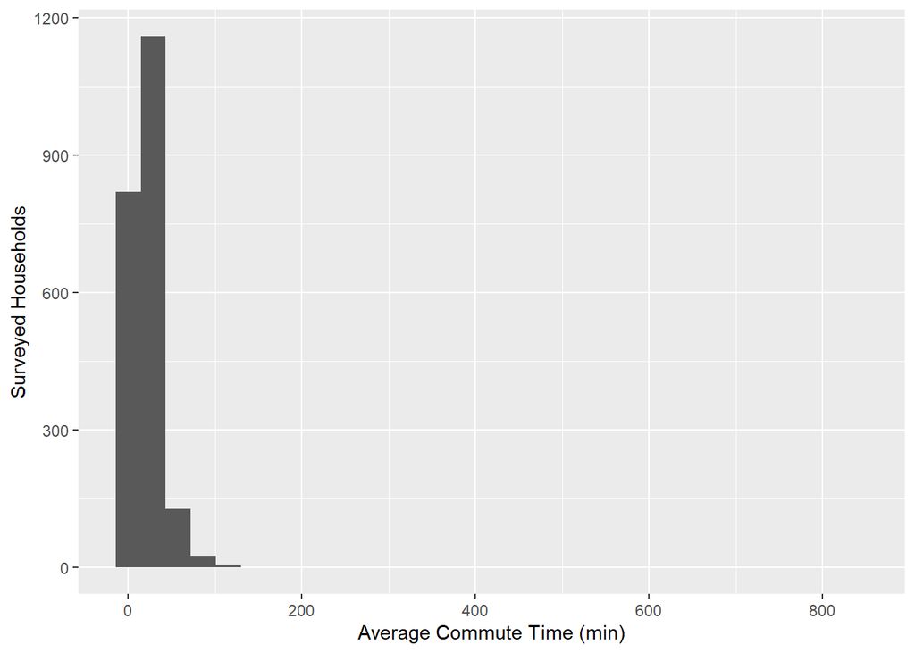

```
##               Value Std. Error  t value       p-value simp p. odds ratio
## explanatory  0.0185     0.0025   7.4884  6.973111e-14       0     1.0186
## 0|1         -1.2096     0.0752 -16.0950  2.767213e-58       0     1.0186
## 1|2          1.0181     0.0730  13.9523  3.047129e-44       0     1.0186
## 2|3          2.8075     0.0999  28.1065 8.153802e-174       0     1.0186
```

**Vehicle Count by Average Commute Time**

|  | *Dependent variable:* |
| --- | --- |
|  | outcome |
| explanatory | 0.018*** |
|  | (0.002) |
| Observations | 2,145 |
| *Note:* | <sup>⋆</sup>p<0.1; <sup>⋆⋆</sup>p<0.05; <sup>⋆⋆⋆</sup>p<0.01 |

There are fewer observations because of the 4,174 NA values - a result of using the `mean()`.

###### *Commute time (total)*

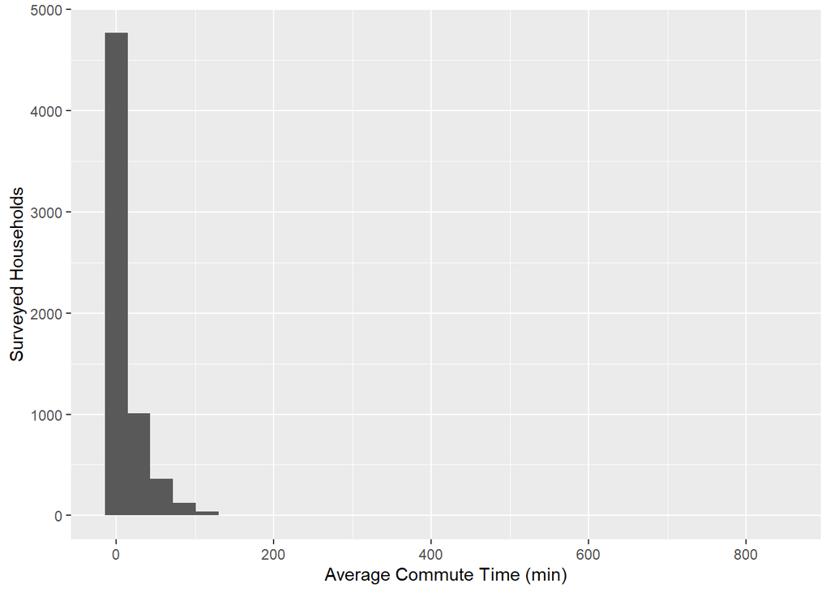

```
##               Value Std. Error  t value       p-value simp p. odds ratio
## explanatory  0.0126     0.0010  12.1323  7.122911e-34       0     1.0127
## 0|1         -1.4276     0.0344 -41.5452  0.000000e+00       0     1.0127
## 1|2          0.7990     0.0297  26.9221 1.212158e-159       0     1.0127
## 2|3          2.6594     0.0503  52.8451  0.000000e+00       0     1.0127
```

**Vehicle Count by Total Commute Time**

|  | *Dependent variable:* |
| --- | --- |
|  | outcome |
| explanatory | 0.013*** |
|  | (0.001) |
| Observations | 6,319 |
| *Note:* | <sup>⋆</sup>p<0.1; <sup>⋆⋆</sup>p<0.05; <sup>⋆⋆⋆</sup>p<0.01 |

Both average household commute time and the total household commute time are positively associated with household vehicle count. Although the coefficients are small, these variables are statistically significant.

##### *Commute Frequency*

Original data at a person level (11,940 survey respondents)

|  | Overall (N=11940) |
| --- | --- |
| commute_freq |  |
| 1 day a week | 72 (1%) |
| 2 days a week | 201 (2%) |
| 3 days a week | 471 (4%) |
| 4 days a week | 817 (7%) |
| 5 days a week | 4561 (38%) |
| 6-7 days a week | 432 (4%) |
| A few times per month | 85 (1%) |
| Less than monthly | 67 (1%) |
| Missing: Skip logic | 2475 (21%) |
| Missing | 2759 (23.1%) |

###### *Survey commute frequency*

The commuting frequency data is aggregated to the household level. The following tables reflect the lowest and highest commuting frequencies of the individuals within each of the surveyed households (6,319).

**Lowest commuting frequencies**

```
## Frequencies
## person_and_household$commute_freq_min
## Type: Character
##
##                               Freq   % Valid   % Valid Cum.   % Total   % Total Cum.
## --------------------------- ------ --------- -------------- --------- --------------
##                1 day a week     72      1.50           1.50      1.14           1.14
##               2 days a week    194      4.03           5.53      3.07           4.21
##               3 days a week    442      9.18          14.71      6.99          11.20
##               4 days a week    695     14.44          29.15     11.00          22.20
##               5 days a week   3027     62.89          92.04     47.90          70.11
##             6-7 days a week    236      4.90          96.95      3.73          73.84
##       A few times per month     81      1.68          98.63      1.28          75.12
##           Less than monthly     66      1.37         100.00      1.04          76.17
##                        <NA>   1506                              23.83         100.00
##                       Total   6319    100.00         100.00    100.00         100.00
```

**Highest commuting frequencies**

```
## Frequencies
## person_and_household$commute_freq_max
## Type: Character
##
##                               Freq   % Valid   % Valid Cum.   % Total   % Total Cum.
## --------------------------- ------ --------- -------------- --------- --------------
##                1 day a week     31      0.64           0.64      0.49           0.49
##               2 days a week     99      2.06           2.70      1.57           2.06
##               3 days a week    236      4.90           7.60      3.73           5.79
##               4 days a week    447      9.29          16.89      7.07          12.87
##               5 days a week   3509     72.91          89.80     55.53          68.40
##             6-7 days a week    403      8.37          98.17      6.38          74.77
##       A few times per month     46      0.96          99.13      0.73          75.50
##           Less than monthly     42      0.87         100.00      0.66          76.17
##                        <NA>   1506                              23.83         100.00
##                       Total   6319    100.00         100.00    100.00         100.00
```

###### *Commute frequency (min)*

Margin of Error

| commute_freq_min | Percentage_0 | Percentage_1 | Percentage_2 | Percentage_3 | Total_0 | Total_1 | Total_2 | Total_3 | Count_0 | Count_1 | Count_2 | Count_3 | sample_size | MOE_Percent |
| --- | --- | --- | --- | --- | --- | --- | --- | --- | --- | --- | --- | --- | --- | --- |
| 1 day a week | 10.1124047 | 8.659015 | 42.46676 | 38.76182 | 2910.9540 | 2492.582 | 12224.469 | 11157.967 | 4 | 27 | 30 | 11 | 72 | 9.693255 |
| 2 days a week | 2.2844424 | 14.739129 | 58.16221 | 24.81422 | 1242.2804 | 8015.143 | 31628.626 | 13493.981 | 23 | 78 | 74 | 19 | 194 | 5.905206 |
| 3 days a week | 9.2427890 | 18.491397 | 38.39437 | 33.87144 | 12236.2133 | 24480.131 | 50829.002 | 44841.246 | 59 | 185 | 155 | 43 | 442 | 3.912234 |
| 4 days a week | 5.8021253 | 27.063878 | 37.68626 | 29.44774 | 10516.6069 | 49054.467 | 68307.995 | 53375.322 | 91 | 310 | 223 | 71 | 695 | 3.119920 |
| 5 days a week | 4.8319272 | 32.223133 | 40.58600 | 22.35894 | 35556.9021 | 237121.700 | 298661.841 | 164533.689 | 479 | 1521 | 816 | 211 | 3027 | 1.494960 |
| 6-7 days a week | 13.9170244 | 34.637128 | 29.60973 | 21.83611 | 8160.3572 | 20309.753 | 17361.901 | 12803.778 | 64 | 113 | 39 | 20 | 236 | 5.354019 |
| A few times per month | 0.5474574 | 9.110322 | 13.57058 | 76.77164 | 195.8954 | 3259.925 | 4855.930 | 27471.014 | 5 | 39 | 23 | 14 | 81 | 9.138889 |
| Less than monthly | 4.4953487 | 18.474915 | 20.90199 | 56.12775 | 718.1960 | 2951.631 | 3339.391 | 8967.206 | 10 | 32 | 17 | 7 | 66 | 10.124275 |
| NA | 14.0583726 | 39.837592 | 33.28564 | 12.81839 | 58156.5773 | 164799.870 | 137695.815 | 53027.037 | 376 | 728 | 304 | 98 | 1506 | 2.119451 |

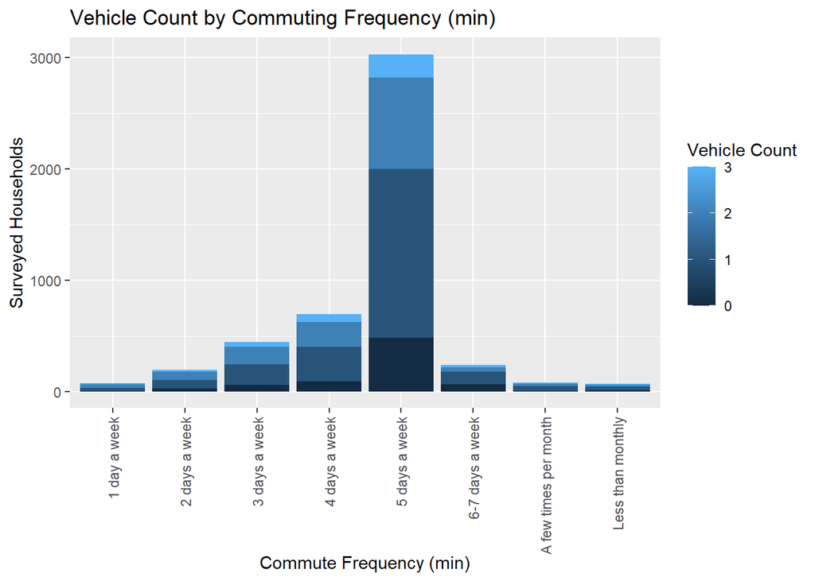

Reference group: 1 day a week

```
##                                    Value Std. Error  t value      p-value
## explanatory2 days a week         -0.4320     0.2523  -1.7121 8.687613e-02
## explanatory3 days a week         -0.5457     0.2323  -2.3498 1.878418e-02
## explanatory4 days a week         -0.6010     0.2261  -2.6584 7.851444e-03
## explanatory5 days a week         -0.9285     0.2176  -4.2675 1.976392e-05
## explanatory6-7 days a week       -1.4441     0.2497  -5.7845 7.274891e-09
## explanatoryA few times per month -0.2673     0.2979  -0.8971 3.696566e-01
## explanatoryLess than monthly     -0.8017     0.3165  -2.5335 1.129396e-02
## 0|1                              -2.5587     0.2181 -11.7302 8.929021e-32
## 1|2                              -0.2769     0.2150  -1.2878 1.978315e-01
## 2|3                               1.6142     0.2176   7.4169 1.198723e-13
##                                  simp p. odds ratio
## explanatory2 days a week          0.0869     0.6492
## explanatory3 days a week          0.0188     0.5794
## explanatory4 days a week          0.0079     0.5483
## explanatory5 days a week          0.0000     0.3952
## explanatory6-7 days a week        0.0000     0.2360
## explanatoryA few times per month  0.3697     0.7655
## explanatoryLess than monthly      0.0113     0.4486
## 0|1                               0.0000     0.6492
## 1|2                               0.1978     0.5794
## 2|3                               0.0000     0.5483
```

**Vehicle Count by Commuting Frequency (min)**

|  | *Dependent variable:* |
| --- | --- |
|  | outcome |
| explanatory2 days a week | -0.432* |
|  | (0.252) |
| explanatory3 days a week | -0.546** |
|  | (0.232) |
| explanatory4 days a week | -0.601*** |
|  | (0.226) |
| explanatory5 days a week | -0.928*** |
|  | (0.218) |
| explanatory6-7 days a week | -1.444*** |
|  | (0.250) |
| explanatoryA few times per month | -0.267 |
|  | (0.298) |
| explanatoryLess than monthly | -0.802** |
|  | (0.316) |
| Observations | 4,813 |
| *Note:* | <sup>⋆</sup>p<0.1; <sup>⋆⋆</sup>p<0.05; <sup>⋆⋆⋆</sup>p<0.01 |

###### *Commute frequency (max)*

Margin of Error

| commute_freq_max | Percentage_0 | Percentage_1 | Percentage_2 | Percentage_3 | Total_0 | Total_1 | Total_2 | Total_3 | Count_0 | Count_1 | Count_2 | Count_3 | sample_size | MOE_Percent |
| --- | --- | --- | --- | --- | --- | --- | --- | --- | --- | --- | --- | --- | --- | --- |
| 1 day a week | 18.657160 | 12.78500 | 28.23815 | 40.31969 | 2884.8816 | 1976.892 | 4366.352 | 6234.472 | 3 | 14 | 8 | 6 | 31 | 14.772536 |
| 2 days a week | 4.914721 | 32.87004 | 37.06144 | 25.15380 | 998.5525 | 6678.397 | 7529.989 | 5110.644 | 16 | 50 | 25 | 8 | 99 | 8.266436 |
| 3 days a week | 13.297733 | 23.86866 | 47.78642 | 15.04719 | 7645.1851 | 13722.662 | 27473.558 | 8650.987 | 43 | 122 | 58 | 13 | 236 | 5.354019 |
| 4 days a week | 6.689852 | 32.99034 | 37.62433 | 22.69548 | 7654.9119 | 37749.430 | 43051.908 | 25969.471 | 71 | 215 | 128 | 33 | 447 | 3.890292 |
| 5 days a week | 4.645447 | 28.80559 | 39.23400 | 27.31497 | 41003.8827 | 254257.758 | 346306.048 | 241100.521 | 512 | 1685 | 1029 | 283 | 3509 | 1.388495 |
| 6-7 days a week | 7.626748 | 20.43094 | 40.24768 | 31.69463 | 10558.4296 | 28284.478 | 55718.674 | 43877.881 | 79 | 164 | 111 | 49 | 403 | 4.097164 |
| A few times per month | 2.921440 | 44.03364 | 24.99104 | 28.05388 | 176.6930 | 2663.220 | 1511.495 | 1696.741 | 4 | 30 | 10 | 2 | 46 | 12.127101 |
| Less than monthly | 7.478357 | 28.61225 | 15.21688 | 48.69251 | 614.8689 | 2352.493 | 1251.129 | 4003.488 | 7 | 25 | 8 | 2 | 42 | 12.691451 |
| NA | 14.058373 | 39.83759 | 33.28564 | 12.81839 | 58156.5773 | 164799.870 | 137695.815 | 53027.037 | 376 | 728 | 304 | 98 | 1506 | 2.119451 |

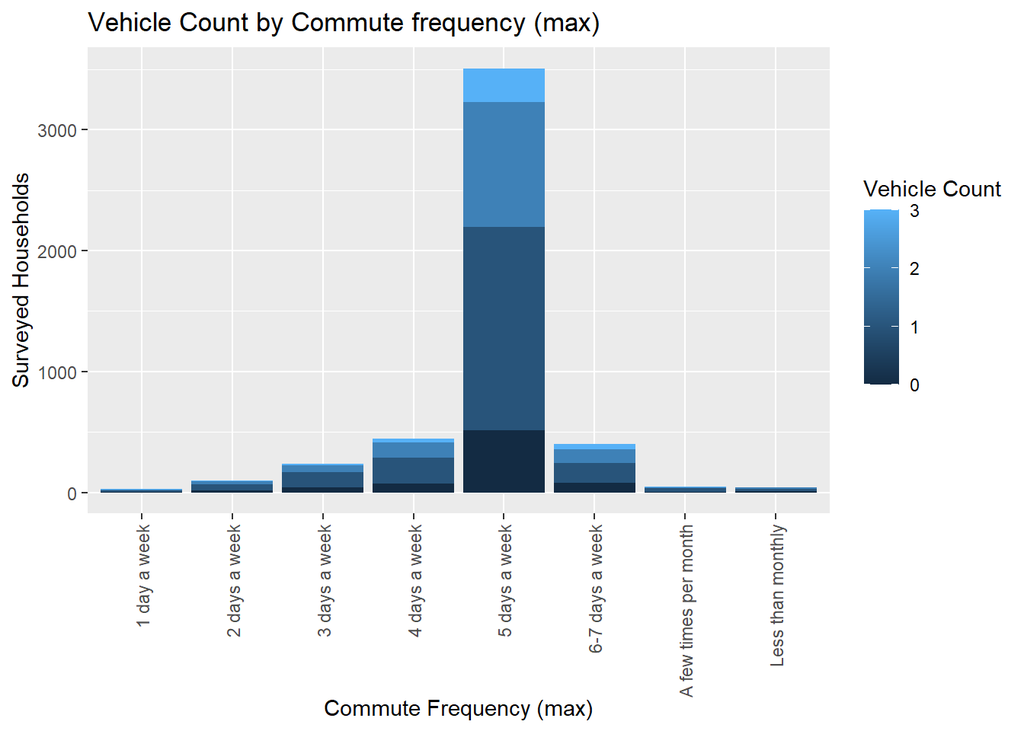

Reference group: 1 day a week

```
##                                    Value Std. Error t value      p-value
## explanatory2 days a week         -0.6259     0.3899 -1.6053 1.084387e-01
## explanatory3 days a week         -0.7885     0.3626 -2.1746 2.965995e-02
## explanatory4 days a week         -0.5569     0.3528 -1.5785 1.144519e-01
## explanatory5 days a week         -0.4835     0.3430 -1.4094 1.587090e-01
## explanatory6-7 days a week       -0.4770     0.3550 -1.3439 1.789750e-01
## explanatoryA few times per month -0.6847     0.4307 -1.5897 1.119122e-01
## explanatoryLess than monthly     -0.9165     0.4434 -2.0669 3.874782e-02
## 0|1                              -2.2273     0.3433 -6.4874 8.731971e-11
## 1|2                               0.0291     0.3418  0.0851 9.321692e-01
## 2|3                               1.9044     0.3439  5.5373 3.071110e-08
##                                  simp p. odds ratio
## explanatory2 days a week          0.1084     0.5348
## explanatory3 days a week          0.0297     0.4545
## explanatory4 days a week          0.1145     0.5730
## explanatory5 days a week          0.1587     0.6166
## explanatory6-7 days a week        0.1790     0.6206
## explanatoryA few times per month  0.1119     0.5042
## explanatoryLess than monthly      0.0387     0.3999
## 0|1                               0.0000     0.5348
## 1|2                               0.9322     0.4545
## 2|3                               0.0000     0.5730
```

**Vehicle Count by Commute frequency (max)**

|  | *Dependent variable:* |
| --- | --- |
|  | outcome |
| explanatory2 days a week | -0.626 |
|  | (0.390) |
| explanatory3 days a week | -0.788** |
|  | (0.363) |
| explanatory4 days a week | -0.557 |
|  | (0.353) |
| explanatory5 days a week | -0.483 |
|  | (0.343) |
| explanatory6-7 days a week | -0.477 |
|  | (0.355) |
| explanatoryA few times per month | -0.685 |
|  | (0.431) |
| explanatoryLess than monthly | -0.916** |
|  | (0.443) |
| Observations | 4,813 |
| *Note:* | <sup>⋆</sup>p<0.1; <sup>⋆⋆</sup>p<0.05; <sup>⋆⋆⋆</sup>p<0.01 |

These results seem to contradict expected trends.

###### *Simplified commute frequency*

The original survey-provided commute frequencies (8) have been simplified into the following 3 categories:

- Less than once a week
- 3 or fewer days a week
- 4 or more days a week

The commuting frequency data is aggregated to the household level. The following tables reflect the lowest and highest commuting frequencies of the individuals within each of the surveyed households (6,319).

**Lowest commuting frequencies (simplified)**

```
## Frequencies
## person_and_household$commute_freq_simp_min
## Type: Factor
##
##                                Freq   % Valid   % Valid Cum.   % Total   % Total Cum.
## ---------------------------- ------ --------- -------------- --------- --------------
##        Less than once a week    147      3.05           3.05      2.33           2.33
##       3 or fewer days a week    708     14.71          17.76     11.20          13.53
##        4 or more days a week   3958     82.24         100.00     62.64          76.17
##                         <NA>   1506                              23.83         100.00
##                        Total   6319    100.00         100.00    100.00         100.00
```

**Highest commuting frequencies (simplified)**

```
## Frequencies
## person_and_household$commute_freq_simp_max
## Type: Factor
##
##                                Freq   % Valid   % Valid Cum.   % Total   % Total Cum.
## ---------------------------- ------ --------- -------------- --------- --------------
##        Less than once a week     88      1.83           1.83      1.39           1.39
##       3 or fewer days a week    366      7.60           9.43      5.79           7.18
##        4 or more days a week   4359     90.57         100.00     68.98          76.17
##                         <NA>   1506                              23.83         100.00
##                        Total   6319    100.00         100.00    100.00         100.00
```

###### *Simp. commute frequency (min)*

Margin of Error

| commute_freq_simp_min | Percentage_0 | Percentage_1 | Percentage_2 | Percentage_3 | Total_0 | Total_1 | Total_2 | Total_3 | Count_0 | Count_1 | Count_2 | Count_3 | sample_size | MOE_Percent |
| --- | --- | --- | --- | --- | --- | --- | --- | --- | --- | --- | --- | --- | --- | --- |
| Less than once a week | 1.766047 | 12.00088 | 15.83356 | 70.39952 | 914.0914 | 6211.556 | 8195.321 | 36438.22 | 15 | 71 | 40 | 21 | 147 | 6.783866 |
| 3 or fewer days a week | 7.603457 | 16.23170 | 43.92529 | 32.23955 | 16389.4478 | 34987.855 | 94682.096 | 69493.19 | 86 | 290 | 259 | 73 | 708 | 3.091144 |
| 4 or more days a week | 5.558091 | 31.40983 | 39.38776 | 23.64432 | 54233.8662 | 306485.921 | 384331.737 | 230712.79 | 634 | 1944 | 1078 | 302 | 3958 | 1.307368 |
| NA | 14.058373 | 39.83759 | 33.28564 | 12.81839 | 58156.5773 | 164799.870 | 137695.815 | 53027.04 | 376 | 728 | 304 | 98 | 1506 | 2.119451 |

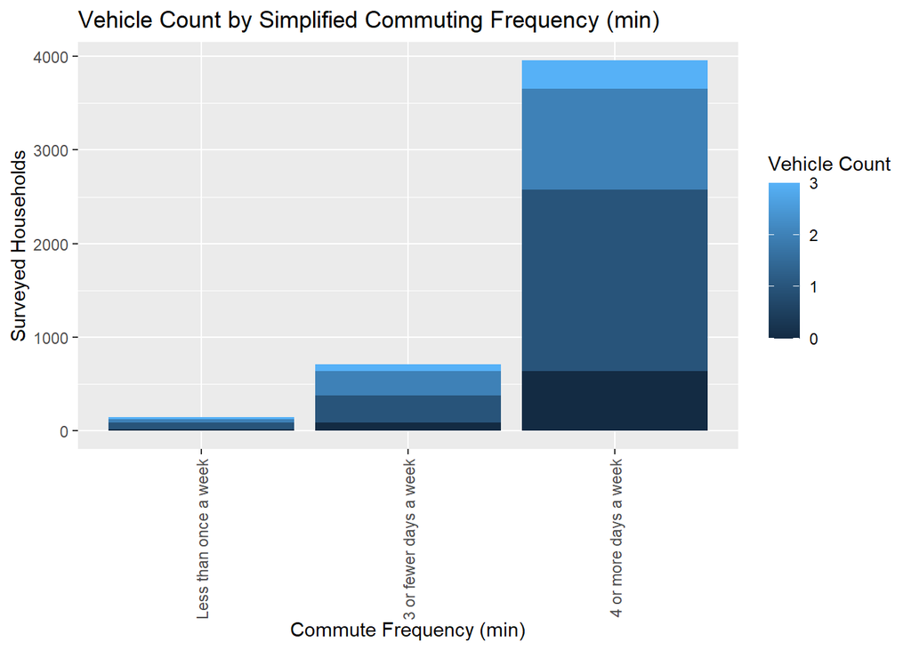

Reference group: Less than once a week

```
##                                     Value Std. Error  t value      p-value
## explanatory3 or fewer days a week  0.0462     0.1692   0.2730 7.848752e-01
## explanatory4 or more days a week  -0.3937     0.1571  -2.5055 1.222728e-02
## 0|1                               -2.0401     0.1578 -12.9326 2.946910e-38
## 1|2                                0.2250     0.1546   1.4550 1.456649e-01
## 2|3                                2.1073     0.1600  13.1706 1.296089e-39
##                                   simp p. odds ratio
## explanatory3 or fewer days a week  0.7849     1.0473
## explanatory4 or more days a week   0.0122     0.6746
## 0|1                                0.0000     1.0473
## 1|2                                0.1457     0.6746
## 2|3                                0.0000     1.0473
```

**Vehicle Count by Simplified Commuting Frequency (min)**

|  | *Dependent variable:* |
| --- | --- |
|  | outcome |
| explanatory3 or fewer days a week | 0.046 |
|  | (0.169) |
| explanatory4 or more days a week | -0.394** |
|  | (0.157) |
| Observations | 4,813 |
| *Note:* | <sup>⋆</sup>p<0.1; <sup>⋆⋆</sup>p<0.05; <sup>⋆⋆⋆</sup>p<0.01 |

###### *Simp. commute frequency (max)*

Margin of Error

| commute_freq_simp_max | Percentage_0 | Percentage_1 | Percentage_2 | Percentage_3 | Total_0 | Total_1 | Total_2 | Total_3 | Count_0 | Count_1 | Count_2 | Count_3 | sample_size | MOE_Percent |
| --- | --- | --- | --- | --- | --- | --- | --- | --- | --- | --- | --- | --- | --- | --- |
| Less than once a week | 5.546986 | 35.14834 | 19.35949 | 39.94518 | 791.562 | 5015.713 | 2762.624 | 5700.229 | 11 | 55 | 18 | 4 | 88 | 8.767879 |
| 3 or fewer days a week | 12.360138 | 23.99200 | 42.20951 | 21.43835 | 11528.619 | 22377.952 | 39369.900 | 19996.103 | 62 | 186 | 91 | 27 | 366 | 4.299276 |
| 4 or more days a week | 5.214926 | 28.20627 | 39.19538 | 27.38342 | 59217.224 | 320291.666 | 445076.630 | 310947.873 | 662 | 2064 | 1268 | 365 | 4359 | 1.245783 |
| NA | 14.058373 | 39.83759 | 33.28564 | 12.81839 | 58156.577 | 164799.870 | 137695.815 | 53027.037 | 376 | 728 | 304 | 98 | 1506 | 2.119451 |

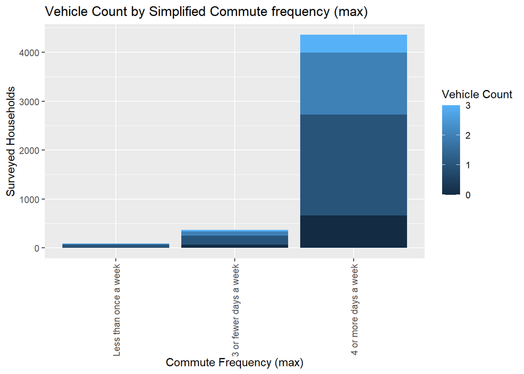

Reference group: Less than once a week

```
##                                     Value Std. Error t value      p-value
## explanatory3 or fewer days a week  0.1110     0.2156  0.5146 6.068549e-01
## explanatory4 or more days a week   0.3014     0.1944  1.5506 1.209880e-01
## 0|1                               -1.4341     0.1940 -7.3934 1.431558e-13
## 1|2                                0.8207     0.1929  4.2536 2.103339e-05
## 2|3                                2.6948     0.1982 13.5953 4.270154e-42
##                                   simp p. odds ratio
## explanatory3 or fewer days a week  0.6069     1.1174
## explanatory4 or more days a week   0.1210     1.3518
## 0|1                                0.0000     1.1174
## 1|2                                0.0000     1.3518
## 2|3                                0.0000     1.1174
```

**Vehicle Count by Simplified Commute frequency (max)**

|  | *Dependent variable:* |
| --- | --- |
|  | outcome |
| explanatory3 or fewer days a week | 0.111 |
|  | (0.216) |
| explanatory4 or more days a week | 0.301 |
|  | (0.194) |
| Observations | 4,813 |
| *Note:* | <sup>⋆</sup>p<0.1; <sup>⋆⋆</sup>p<0.05; <sup>⋆⋆⋆</sup>p<0.01 |

Household commute frequency does not have a clear relationship with household vehicle count based on the simplification and aggregation techniques.

The lack of statistical power for the households with individuals commuting less than once a week is likely because of the small sample size (147/6,319 ~2% of total sample) and the large MOE.